# Mieten in Deutschland

Worin liegen Probleme und Schwierigkeiten im deutschen Mietmarkt

# Motivation

Die Mietpreise in Deutschland spielen eine wichtige Rolle für eine Vielzahl der deutschen Bevölkerung, doch nicht alle Gemeinden sind gleichermaßen von hohen Mieten betroffen. Faktoren wie die Lage einer Stadt, das Angebot an Wohnraum, das Alter der Gebäude oder der Familienstand der Bewohner beeinflussen die Höhe der Mieten. Dies werden Sie in diesem Projekt anhand von Zensus-Daten auf Gemeindeebene für das Jahr 2022 genau untersuchen. Besonders interessant ist dabei, wie sich Mietpreise nicht nur zwischen verschiedenen Städten, sondern auch innerhalb einer Stadt unterscheiden. Sie werden feststellen, dass die Ursachen für diese Mietunterschiede komplex und vielschichtig sind. Ihre Aufgabe ist es, durch fundierte Analysen herauszuarbeiten, welche Faktoren den größten Einfluss auf die Mietentwicklung haben. Auf Basis dieser Erkenntnisse könnten Sie Handlungsempfehlungen geben, die Politik und Stadtplaner nutzen können, um die Mietpreisentwicklung besser zu steuern und Wohnraum gerechter zu gestalten.

# Datengrundlage

In diesem Projekt werden Sie mit mehreren unterschiedlichen Datensätzen arbeiten. Zum Einen werden Sie Zensusdaten aus dem Jahr 2022 zur Demografie genauer betrachten. Zum Anderen werden Sie Daten zur Wohnungszählung in deutschen Gemeinden und Städten untersuchen. Schließlich benötigen Sie die dazugehörigen Kartendaten, um die Informationen später anschaulich visualisieren zu können. Dort werden Sie die Details der Karten einlesen und darüber hinaus Zahlen zu Mieten selbstständig herunterladen und importieren.

## Einlesen

Mittlerweile wohnen knapp 54% der Menschen in Deutschland zur Miete (Stand 2022). Somit ist Deutschland das Mieterland Nummer 1 in Europa. Im Vergleich dazu haben Länder wie Frankreich (36,6%), Italien (25,7%) oder Spanien (24%) einen deutlich geringeren Anteil an Mietern. Für die Politik ist es besonders interessant zu erfahren, wie sich nun die Mieten in den unterschiedlichen Gemeinden in Deutschland verteilen und ob es Regionen gibt, wo es besonders schwer wird eine neue Wohnung zu finden. Um dies zu beleuchten, sollen Sie nun die nachfolgenden Datensätze genauer analysieren.

1. Lesen Sie den Datensatz `Demografie_Zensus.csv` ein und speichern diesen als `demografie`. Der Datensatz `demografie` enthält für jede Gemeinde mehrere Beobachtungen. Dies liegt daran, dass für jede Altersgruppe der Personen eine eigene Beobachtung vorliegt. Allerdings ist der Datensatz im long-Format, d.h. nicht tidy und damit nicht so, wie Sie ihn für die weitere Datenanalyse benötigen. Nun soll der Datensatz so abgeändert werden, dass jede Gemeinde nur noch eine Beobachtung darstellt. Passen Sie den Datensatz so an, dass Sie für jede `Altersgruppe` eine eigene Spalte erstellen und dort jeweils die Anzahl der Menschen, die Sie der Spalte `Anzahl pro Altersgruppe` entnehmen können, eingetragen wird.

Darüberhinaus sollen Sie nun einen weiteren Datensatz `Wohnungen_Zensus.csv` einlesen, welcher Informationen zu den einzelnen Wohnungen in den Gemeinden enthält. Speichern Sie den Datensatz in der Variable `wohnungen` ab. Vereinen Sie ihren Datensatz `demografie` mit dem Datensatz `wohnungen` und speichern Sie diesen als `zensus_daten` ab. Verwenden Sie für ihren “Join” die Variable `Regionalschlüssel`.

Beantworten Sie anschließend die Frage, welche Art von “Join” sich in diesem Fall anbietet und warum?

```
## # A tibble: 6 × 70
##   Name_Gemeinde Landkreis         `0_Insgesamt_` Regionalschlüssel GESCHLECHT__1
##   <chr>         <chr>                      <dbl>             <dbl>         <dbl>
## 1 Aach          Trier-Saarburg              1096       72355007001           522
## 2 Aach, Stadt   Konstanz                    2285       83355001001          1149
## 3 Aachen, Stadt Städteregion Aac…         261178       53340002002        136095
## 4 Aalen, Stadt  Ostalbkreis                67139       81365001088         33402
## 5 Aarbergen     Rheingau-Taunus-…           6225       64390001001          3050
## 6 Aasbüttel     Steinburg                    149       10615168001            83
## # ℹ 65 more variables: GESCHLECHT__2 <dbl>, Staatsange_kurz__1 <dbl>,
## #   Staatsange_kurz__2 <dbl>, FAMSTND_KURZ__1 <dbl>, FAMSTND_KURZ__2 <dbl>,
## #   FAMSTND_KURZ__3 <dbl>, FAMSTND_KURZ__4 <dbl>, FAMSTND_KURZ__5 <dbl>,
## #   Einwanderungserf_ausf__21 <dbl>, Einwanderungserf_ausf__22 <dbl>,
## #   Einwanderungserf_ausf__3 <dbl>, Einwanderungserf_ausf__1 <dbl>,
## #   Alter_infr__01 <dbl>, Alter_infr__02 <dbl>, Alter_infr__03 <dbl>,
## #   Alter_infr__04 <dbl>, Alter_infr__05 <dbl>, Alter_infr__06 <dbl>, …
```

In diesem Fall bietet sich der Full Join an, da bei einem Left, Right oder Inner Join Daten verloren gehen können, falls in einer der beiden Datensätze eine Gemeinde fehlt, die im anderen Datensatz enthalten ist. Der Full Join hingegen behält alle Daten von beiden Datensätzen und füllt eventuell fehlende Daten mit NA auf.

2. Schränken Sie nun Ihren erstellten Datensatz auf folgende Variablen ein:
- `Name_Gemeinde`
- `Landkreis`
- `0_Insgesamt_`
- `Regionalschlüssel`
- `Alter_infr__` (01 bis 11)
- `FAMSTND_KURZ__` (1 bis 5)
- `Einwanderungserf_ausf__1`
- `Einwanderungserf_ausf__21`
- `Einwanderungserf_ausf__22`
- `Einwanderungserf_ausf__3`
- `Staatsange_kurz__1`
- `Staatsange_kurz__2`
- `BAUJAHR_10JA__` (01 bis 10)
- `WOHNFLAECHE_20S__` (01 bis 10)
- `QMMIETE`
- `LEQ`
- `ETQ`
- `FLAECHE`
- `Wohnungen_gesamt`

Beschreiben Sie weiterhin den Datensatz. Orientieren Sie sich hierbei an folgenden Fragen und nutzen Sie das bereitgestellte README zum Datensatz:

- Was ist eine Beobachtung?
- Wie viele Variablen hat der Datensatz?
- Welche Variablen enthält der Datensatz? Bitte beschreiben Sie diese Variablen kurz!
- Welche Städte mit mehr als 500.000 Einwohnern sind im Datensatz?
- In wie viel Prozent der Fälle haben Sie Informationen zu allen Variablen einer Beobachtung?

**Eine Beobachtung im Datensatz ist, nach der Transformation vom long- ins wide-format, eine Gemeinde.**

**Der Datensatz hat nach der Einschränkung in dieser Aufgabe noch folgende 51 Variablen:**

*Regionalschlüssel:*  
Der amtliche Regionalschlüssel (ARS) der jede Gemeinde spezifisch identifiziert, dient als “Primärschlüssel” und wird von den Statistischen Ämtern der Bundesländer einheitlich vergeben.

*Name_Gemeinde:*  
Der Name der Gemeinde.

*Landkreis:*  
Der Name des Landkreises.

*0_Insgesamt_*:  
Anzahl Einwohner der Gemeinde

*Alter_infr__ (01 bis 11):*  
Elf Variablen, die Altersgruppen beschreiben und die Anzahl der Personen, die in diesem Landkreis in dieser Altersgruppe sind angeben. Aufgeteilt wird in folgende Altersklassen: <3, 3-5, 6-9, 10-15, 16-18, 19-24, 25-39, 40-59, 60-66, 67-74 und >75 Jahre alt.

*FAMSTND_KURZ__(1 bis 5):*  
Fünf Variablen, die die Anzahl an Personen in der Gemeinde in folgenden Familienständen angeben:  
1 = Ledig  
2 = Verheiratet / eingetragene Lebenspartnerschaft  
3 = Verwitwet / Eingetragene(r) Lebenspartner(in) gestorben  
4 = Geschieden / eingetragene Lebenspartnerschaft aufgehoben  
5 = ohne Angabe

*Einwanderungserf_ausf__(1, 21, 22, 3):*  
Anzahl an Personen in der Gemeinde…  
1 = …ohne Einwanderungsgeschichte  
21 = …die eingewandert sind  
22 = …die Nachkommen von Eingewanderten sind  
3 = …mit einseitier Einwaderungsgeschichte

*Staatsange_kurz__(1 und 2):*  
Anzahl Personen in der Gemeinde…  
1 = …mit deutscher Staatsangehörigkeit  
2 = …mit ausländischer Staatsangehörigkeit (einschl. Personen mit einer Staatsangehörigkeit „Staatenlos“, „Ungeklärt“ und „Ohne Angabe“)

*BAUJAHR_10JA__(01 bis 10):*  
Anzahl Wohnungen in der Gemeinde in Gebäuden mit Wohnraum mit Baujahr… 01 = …vor 1919  
02 = …von 1919 bis 1949  
03 = …von 1950 bis 1959  
04 = …von 1960 bis 1969  
05 = …von 1970 bis 1979  
06 = …von 1980 bis 1989  
07 = …von 1990 bis 1999  
08 = …von 2000 bis 2009  
09 = …von 2010 bis 2015  
10 = …von 2016 und später

*WOHNFLAECHE_20S__(01 bis 10):*  
Anzahl Wohnungen in der Gemeinde in Gebäuden mit Wohnraum mit einer Fläche von…  
01 = …von unter 40m²  
02 = …von 40m² bis 59m²  
03 = …von 60m² bis 79m²  
04 = …von 80m² bis 99m²  
05 = …von 100m² bis 119m²  
06 = …von 120m² bis 139m²  
07 = …von 140m² bis 159m²  
08 = …von 160m² bis 179m²  
09 = …von 180m² bis 199m²  
010 = …von 200m² und mehr

*QMMIETE:*  
Diese Variable beschreibt die durchschnittliche Nettokaltmiete pro Quadratmeter in der Gemeinde (in €/m²). Sie berechnet sich, indem man die Summe der Quadratmetermieten der Wohnungen durch die Summe der Wohnungen teilt. Die Berechnung erfolgt für alle vermietete Wohnungen in Wohngebäuden und schließt Wohngebäude und mietfrei überlassene Wohnungen aus.

*LEQ:*  
Diese Variable beschreibt die Leerstandsquote von Wohnungen und somit den Anteil der leerstehenden Wohnungen an allen Wohnungen in Wohngebäuden ohne Berücksichtigung von Ferien- und Freizeitwohnungen, Wohnheimen sowie gewerblich genutzten Wohnungen.

*ETQ:*  
Diese Variable beschreibt die Eigentümerquote und somit den Anteil der von Eigentümerinnen und Eigentümern bewohnten Wohnungen an allen bewohnten Wohnungen in Wohngebäuden ohne Berücksichtigung von leer stehenden Wohnungen, Ferien- und Freizeitwohnungen, Wohnheimen sowie gewerblich genutzte Wohnungen.

*FLAECHE:*  
Diese Variable beschreibt die durchschnittliche Fläche je Wohnung in der Gemeinde in m². Sie berechnet sich, indem man die Gesamgtfläche aller Wohnungen in m² durch die Anzahl der Wohnungen teilt. Dies geschieht ohne Berüchsichtigung von gewerblich genutzten Wohnungen und für Wohnungen in Wohngebäuden (ohne Wohnheime)

*Wohnungen_gesamt:*  
Diese Variable gibt die Gesamtanzahl der Wohnungen in den einzelnen Gemeinden an.

**Folgende Städte im Datensatz haben mehr als 500.000 Einwohner:**

```
##  [1] "Berlin, Stadt"                 "Bremen, Stadt"
##  [3] "Dortmund, Stadt"               "Dresden, Stadt"
##  [5] "Duisburg, Stadt"               "Düsseldorf, Stadt"
##  [7] "Essen, Stadt"                  "Frankfurt am Main, Stadt"
##  [9] "Hamburg, Freie und Hansestadt" "Hannover, Landeshauptstadt"
## [11] "Köln, Stadt"                   "Leipzig, Stadt"
## [13] "München, Landeshauptstadt"     "Nürnberg"
## [15] "Stuttgart, Landeshauptstadt"
```

**Prozent der Fälle, in denen es Informationen zu allen Variablen einer Beobachtung gibt:**

```
## [1] 0.9859077
```

3. Erstellen Sie in einem nächsten Schritt weitere Variablen, die Sie in ihrer Analyse benötigen. Diese Variablen sollen folgende Eigenschaften umfassen:
- Je eine Variable für den Anteil kleiner, mittlerer und großer Wohnungen, wobei kleine Wohnungen (<= 59 m²), mittlere Wohnungen (60 - 159 m²) und große Wohnungen (>= 160 m²) als Anteil an den `Wohnungen_gesamt` abgebildet werden sollen.
- Je eine Variable für den Anteil neuer und alter Wohnungen. Neue Wohnungen umfassen alle Wohnungen, die ab 2010 gebaut wurden und alte Wohnungen sind alle Wohnungen vor 1950. Auch hier soll wieder der Anteil an allen Wohnungen (`Wohnungen_gesamt`) berechnet werden.
- Das Verhältnis von Personen mit deutscher Staatsangehörigkeit zu allen Bürgern der Gemeinde einschliesslich Personen mit ausländischer Staatsangehörigkeit und Personen mit dem Status “staatenlos”, “ungeklärt” und “ohne Angabe” über `Staatsange_kurz__1` und `Staatsange_kurz__2`. Hier soll der Anteil deutscher Bürger im Verhältnis zu allen Bürgern der Gemeinde bestimmt werden.

*Hinweis:* Runden Sie die Werte für die neu erstellte Variable sinnvoll!

4. Um Karten wie bspw. in der Case Study zu erstellen, benötigen Sie Kartendaten in Form von Shapefiles (Endung .shp). In einer späteren Analyse sollen Sie die einzelnen Städte, bzw. deren Bezirke visualisieren. Hierzu müssen Sie zuerst die nötigen Shape-Files einlesen und Details zu den einzelnen Bezirken herunterladen. Sie sollen Analysen auf Basis von 1km Gitterdaten durchführen. Deshalb sollten Sie sich [diese Geogitter-Daten für die Nettokaltmieten vom statistischen Bundesamt herunterladen](https://www.zensus2022.de/static/Zensus_Veroeffentlichung/Zensus2022_Durchschn_Nettokaltmiete.zip). Speichern Sie die zip-Datei im Ordner `Daten` ab. Weiterhin sollen Sie [die Geogitter-Daten für die Leerstandsquoten herunterladen](https://www.zensus2022.de/static/Zensus_Veroeffentlichung/Marktaktive_Leerstandsquote_in_Gitterzellen.zip). Speichern Sie auch diese im Ordner `Daten` ab und lesen Sie anschließend die .csv-Dateien für Nettokaltmiete und Leerstandsquote (für das 1km-Gitter) ein. Weiterhin benötigen Sie die Karteninformationen für die Visualisierung der Daten. Diese befinden sich in der Datei `Shapefile_Zensus.shp`. Lesen Sie diese mit Hilfe von `st_read()` ein und speichern Sie als `shape_file` ab. Benennen Sie die Variablen in `shape_file` folgendermaßen um:
- gemndnm = Name_Gemeinde
- x_mp_1k = x_mp_1km
- y_mp_1k = y_mp_1km
- gttr1km = gitter1km

Joinen Sie nun noch die beiden Dataframes zu Miete und Leerstandsquote zu `shape_file` hinzu. Verwenden Sie `y_mp_1km` und `x_mp_1km` als Joinvariable.

*Hinweis:* Im ersten Teil der Case-Study wird eine ZIP-Datei in R entpackt. Gehen Sie hier gleich vor!

# Konsistenzcheck

Nun haben Sie alle Daten zusammen, die Sie für die Analyse der Mieten in Deutschland für das Jahr 2022 benötigen. Somit können Sie nun beginnen, die ersten Analysen zu tätigen!

5. Im Datensatz `zensus_daten`, welchen Sie zuvor eingelesen, aufgearbeitet und zusammengefügt haben, befinden sich einige große deutsche Städte. Sie möchten nun gerne die Daten, welche Sie dort aufbereitet haben, verifizieren. Dafür sollten Sie sich eine externe Quelle suchen, auf deren Basis Sie die Gesamtbevölkerung der unten aufgeführten großen Städte in Deutschland mit denen aus dem Datensatz vergleichen. Die Bevölkerungszahlen in ihrem Datensatz stammen aus dem Jahr 2022.

Erstellen Sie eine Tabelle mit allen nachfolgenden Städten aus dem Datensatz und deren Einwohnern. Achten Sie auf eine schöne Darstellung ihrer Tabelle mittels der Pakete `kableExtra` oder `gt`.

Im Detail sollen folgende Städte in der Tabelle genauer betrachtet werden:

- “Berlin, Stadt”, “Hamburg, Freie und Hansestadt”, “München, Landeshauptstadt”, “Köln, Stadt”, “Frankfurt am Main, Stadt”, “Stuttgart, Landeshauptstadt”, “Düsseldorf, Stadt”, “Leipzig, Stadt”, “Augsburg”, “Ingolstadt”, “Ulm, Universitätsstadt”, “Reutlingen, Stadt”

Sind die Anzahl der Einwohner in ihren Daten korrekt? Nutzen Sie eine externe Datenquelle (bitte benennen und in ihrer Antwort verlinken) und führen Sie einen kurzen Konsistenzcheck durch.

Einwohnerzahlen der Städte

| Daten Städte | Daten Einwohner nach Datensatz | Daten Einwohner nach Statistikportal.de |
| --- | --- | --- |
| Augsburg | 294.647 | 301.033 |
| Berlin, Stadt | 3.596.999 | 3.755.251 |
| Düsseldorf, Stadt | 611.258 | 629.047 |
| Frankfurt am Main, Stadt | 743.268 | 773.068 |
| Hamburg, Freie und Hansestadt | 1.808.846 | 1.892.122 |
| Ingolstadt | 136.468 | 141.029 |
| Köln, Stadt | 1.017.355 | 1.084.831 |
| Leipzig, Stadt | 598.899 | 616.093 |
| München, Landeshauptstadt | 1.478.638 | 1.512.491 |
| Reutlingen, Stadt | 116.925 | 117.547 |
| Stuttgart, Landeshauptstadt | 610.458 | 632.865 |
| Ulm, Universitätsstadt | 127.116 | 128.928 |

Diese Daten stammen von [Statistikportal.de](https://www.statistikportal.de/de/gemeindeverzeichnis). Es fällt auf, dass die Bevölkerungszahlen dort für all diese Großstädte leicht über den Zahlen aus dem Datensatz liegen. Grund dafür könnte sein, dass die Bevölkerungsdaten von [Statistikportal.de](https://www.statistikportal.de/de/gemeindeverzeichnis) zum Stichtag 31.12.2022 ermittelt wurden, während die hier verwendeten Daten aus dem Zensus 2022 zum Stichtag 15.05.2022 stammen. Die Abweichungen sind von geringem Ausmaß, sodass davon ausgegangen werden kann, dass die Daten korrekt sind.

# Deskriptive Analysen

6. Schauen Sie sich in einem nächsten Schritt an, wie die Variablen im Datensatz `zensus_daten` über alle Gemeinden und Städte hinweg verteilt sind. Konkret sollten Sie eine Tabelle erstellen, welche Informationen zu folgenden Variablen enthält:
- verschiedene Baujahre der Wohnungen
- durchschnittlicher Quadratmeterpreis
- Leerstandsquote
- Eigentümerquote
- durchschnittliche Wohnfläche
- Anteil kleiner, mittlerer und großer Wohnungen
- Einwohner

Berechnen Sie zu jeder Variablen den Mittelwert, den Median, das Minimum, das Maximum, die Standardabweichung, sowie das 25%- und das 75%- Quantil bezogen auf alle Gemeinden. Bei den Variablen Leerstandsquote, Eigentümerquote, durchschnittliche Wohnfläche, durchschnittlicher Quadratmeterpreis und Anteil kleiner, mittlerer und großer Wohnungen soll der Mittelwert als gewichteter Mittelwert nach der absoluten Anzahl an Wohnungen berechnet werden. Heben Sie die Variablen in ihrer Tabelle entsprechend hervor, bei denen sie den gewichteten Mittelwert bestimmt haben.

Beschreiben und interpretieren Sie Ihre Tabelle. Begründen Sie auch, warum es bei den genannten Variablen sinnvoll ist, den nach Anzahl der Wohnungen gewichteten Mittelwert zu verwenden. Würde es ihrer Ansicht nach Sinn machen, statt nach Wohnungen nach Einwohnern zu gewichten? Begründen Sie auch, bei welchen Variablen eine Betrachtung der Mittelwerte, Standardabweichungen und Quantile ihrer Ansicht nach als sinnvoll erscheint. Wo ist dies weniger gut geeignet? Bei welchen Variablen gibt es Auffälligkeiten? Gibt es Ausreißer nach oben oder unten?

Achten Sie auf eine schöne Darstellung ihrer Tabelle mittels der Pakete `kableExtra` oder `gt`!

*Hinweis 1:* Wenn bei den Variablen Wohnungen_klein, Wohnungen_mittel und Wohnungen_groß Werte mit `NaN` oder `Inf` auftauchen, so ersetzen Sie diese durch `NAs`.

*Hinweis 2:* Die Anzahl der Wohnungen nach Alters- bzw. Baujahrsgruppen können den Variablen entnommen werden, welche mit `BAUJAHR_10JA__` beginnen.

Statistische Auswertung der Variablen

Mittelwert, Median, Minimum, Maximum, Standardabweichung, 25%- und 75%-Quantil

| Variable | Mittelwert | Median | Minimum | Maximum | Standardabweichung | 25%-Quantil | 75%-Quantil |
| --- | --- | --- | --- | --- | --- | --- | --- |
| Baujahr vor 1919 | 527,59 | 111,00 | 0,0 | 520.700,00 | 5.692,47 | 50,00 | 316,00 |
| Baujahr zwischen 1919 und 1949 | 410,88 | 69,00 | 0,0 | 281.150,00 | 3.526,98 | 28,00 | 221,00 |
| Baujahr zwischen 1950 und 1959 | 458,39 | 60,00 | 0,0 | 193.475,00 | 3.943,25 | 20,00 | 198,00 |
| Baujahr zwischen 1960 und 1969 | 608,00 | 94,00 | 0,0 | 261.728,00 | 4.351,18 | 30,00 | 337,50 |
| Baujahr zwischen 1970 und 1979 | 579,82 | 113,00 | 0,0 | 239.857,00 | 3.426,96 | 33,00 | 388,50 |
| Baujahr zwischen 1980 und 1989 | 395,81 | 91,00 | 0,0 | 223.683,00 | 2.676,07 | 29,00 | 295,00 |
| Baujahr zwischen 1990 und 1999 | 479,42 | 124,00 | 0,0 | 141.456,00 | 2.131,73 | 39,00 | 407,00 |
| Baujahr zwischen 2000 und 2009 | 251,93 | 69,00 | 0,0 | 57.008,00 | 1.114,23 | 23,00 | 204,00 |
| Baujahr zwischen 2010 und 2015 | 129,78 | 26,00 | 0,0 | 45.389,00 | 828,19 | 8,00 | 88,00 |
| Baujahr ab 2016 | 155,93 | 33,00 | 0,0 | 80.878,00 | 1.101,49 | 9,00 | 115,00 |
| Nettokaltmiete pro QM | 7,00 | 5,53 | 0,0 | 13,84 | 1,38 | 4,82 | 6,46 |
| Leerstandsquote | 4,34 | 4,74 | 0,0 | 50,00 | 3,11 | 3,45 | 6,58 |
| Eigentümerquote | 44,36 | 68,77 | 13,5 | 100,00 | 12,72 | 60,22 | 76,11 |
| Durchschnittliche Fläche pro Wohnung | 94,32 | 116,20 | 64,9 | 239,54 | 15,41 | 104,98 | 125,11 |
| Anteil Wohnungen unter 60m² | 0,23 | 0,09 | 0,0 | 0,59 | 0,08 | 0,06 | 0,14 |
| Anteil Wohnungen zwischen 60m² und 160m² | 0,68 | 0,73 | 0,0 | 1,00 | 0,06 | 0,69 | 0,76 |
| Anteil Wohungen über 160m² | 0,09 | 0,16 | 0,0 | 1,00 | 0,08 | 0,11 | 0,21 |
| Einwohner | 7.668,39 | 1.797,00 | 9,0 | 3.596.999,00 | 49.519,18 | 655,25 | 5.505,00 |

Die blau markierten Mittelwerte sind nach der absoluten Anzahl an Wohnungen in der Gemeinde gewichtet.

Beschreibung:

Zu sehen ist eine deskriptive Tabelle, die Mittelwert, Median, Minimum, Maximum, Standardabweichung, 25%-Quantil und 25%-Quantil mehrerer Variablen in den 10.786 deutschen Gemeinden zeigt. Die Variablen sind die Anzahl der Wohnungen, die in gewissen Perioden entstanden sind (vor 1919, 1919-1949, 1950-1959, 1960-1969, 1970-1979, 1980-1989, 1990-1999, 2000-2009, 2010-2015, ab 2016), die durchschnittliche Nettokaltmiete pro Quadratmeter, die Leerstandsquote, die Eigentümerquote, die durchschnittliche Fläche pro Wohnung, der Anteil von Wohnungunen unter 60m², zwischen 60m² und 160m² und über 60m² sowie die Einwohnerzahl. Dabei sind die Mittelwerte der Nettokaltmiete/m², Leerstandsquote, Eigentümerquote und durchschnittlicher Fläche pro Wohnung gewichtet nach der absoluten Anzahl an Wohnungen

Insbesondere bei Variablen wie Baujahr, Miete und Fläche ist die Betrachtung von Mittelwerten und Quantilen sinnvoll, da diese eine breite Streuung aufweisen, bei Variablen wie dem Anteil an Wohnungen zwischen 60m² und 160m² hingegen ist die Betrachtung weniger sinnvoll, da die Streuung sehr klein ist. Auffälligkeiten gibt es bei den Bauperioden: Trotz Mittelwerten und Medianen zwischen 26 und 608 gibt es sehr hohe Maxima, am höchsten bei der Bauperiode vor 1919 mit 520.700. Der Grund für diese statistischen Ausreißer sind ein paar sehr große Städte, die durch ihre hohe Anzahl an Wohnungen den Schnitt nach oben treiben.

7. Die Verteilung des Alters der Wohnungen scheint bereits ein Faktor zu sein, der sich auf den Mietpreis auswirken kann, da doch deutlich weniger Wohnungen ab den 2000er Jahren gebaut wurden. Nun sollen Sie etwas tiefer in ihren Datensatz eintauchen und weitere Faktoren analysieren, die sich zum einen zwischen Städten und Gemeinden unterscheiden und darüberhinaus herausfinden, ob diese Faktoren einen Einfluss auf den Mietpreis haben:

Erstellen Sie 4 Punktdiagramme in denen Sie

- die durchschnittliche Fläche je Wohnung,
- die Leerstandsquote je Gemeinde,
- Anteil alter Wohnungen je Gemeinde,
- Anteil neuer Wohnungen je Gemeinde,

auf der x-Achse abtragen und auf der y-Achse jeweils die durchschnittliche Nettokaltmiete pro Quadratmeter. Verwenden Sie hier nun alle Gemeinden im Datensatz, um ein Gesamtbild zu erhalten und ordnen Sie die 4 Diagramme so an, dass ein Vergleich zwischen den Schaubildern schnell und einfach möglich ist. Beschreiben und interpretieren Sie die Diagramme. Gehen Sie hierbei insbesondere auf folgende Fragen ein:

- Welche Variablen scheinen besonders stark mit dem Mietpreis korreliert zu sein?
- Was könnte die Zusammenhänge erklären?

*Hinweis:* Achten Sie darauf das bei nebeneinander angeordneten Grafiken die y-Achse gleich sein sollte.

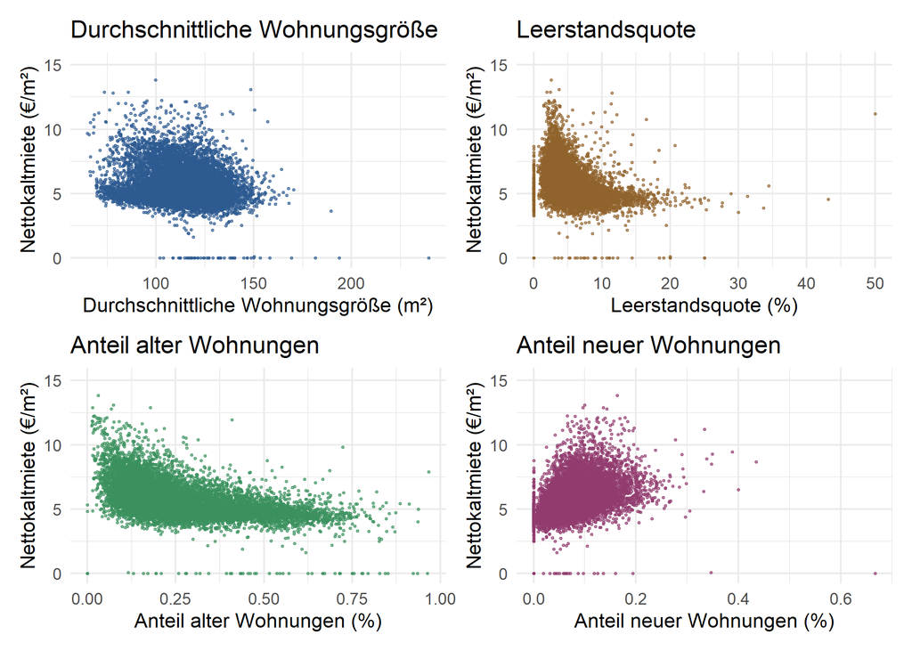

Beobachtungen:

Zu sehen sind vier Punktdiagramme, die die Verteilung der durchschnittlichen Nettokaltmiete pro m²(in €) in deutschen Gemeinden in Abhängigkeit von folgenden vier Faktoren zeigen: Durchschnittliche Wohnungsgröße (in m²), Leerstandsquote (in %), Anteil alter Wohnungen (in %) und Anteil neuer Wohnungen (in %).

Bei der durchschnittlichen Wohungsgröße kann man eine große Streuung erkennen, es zeigt sich jedoch der Trend, dass eine höhere Durchschnittliche Wohnungsgröße in einer Gemeinde zu einer niedrigeren Nettokaltmiete führt. Zudem wird die Streuung mit steigender Wohnungsgröße geringer. Eine Korrelation ist trotz der hohen Streuung erkennbar.

Bei der Leerstandsquote ist ein regressiver Verlauf erkennbar, das heißt, während die Nettokaltmiete bei steigender Leerstandsquote im Mittel sinkt, wird die Steigung der mittleren Nettokaltmiete immer geringer. Dadurch ist, trotz des sinkenden Mittels, keine besonders hohe Korrelation zu erkennen, da es viele Wohnungen mit niedrigem Leerstand und hoher Miete, viele Wohnungen mit niedrigem Leerstand und niedriger Nettokaltmiete und viele Wohnungen mit hohem Leerstand und niedrigen Mieten gibt. Lediglich die Kombination hoher Leerstand und hohe Nettokaltmieten tritt nur in ein paar Einzelfällen auf.

Ein schöner linearer Zusammenhang ist beim Anteil alter Wohnungen in den Gemeinden zu sehen. Hier ist eine negative Korrelation zu erkennen, sprich je höher der Anteil an alten Wohnungen, desto niedriger ist die Nettokaltmiete. Zudem nimmt die Streuung mit steigendem Anteil alter Wohnungen ab.

Beim Anteil neuer Wohnungen ist die Korrelation wie kaum anders zu erwarten genau umgekehrt. Hier ist die Korrelation eindeutig positiv, also steigt die Nettokaltmiete mit steigendem Anteil neuer Wohnungen während die Streuung ebenfalls zunimmt.

Interpretation:

Der negative Effekt bei der durchschnittlichen Wohnungsgröße könnte darauf zurückzuführen sein, dass kleinere Wohnungen häufig höhere Quadratmeterpreise haben als größere Wohnungen ([Quelle](https://link.springer.com/article/10.1365/s41056-021-00053-9#Sec11)). Ein weiterer Faktor dürfte die Tatsache sein, dass Wohnungen auf dem Land, wo die Mietpreise niedriger sind, meist größer sind als in der Stadt, da mehr Platz ist und weniger Nachfrage herrscht.

Gemeinden mit höheren Leerstandsquoten weisen auf eine im Vergleich zum Angebot niedrige Nachfrage hin, wodurch ganz natürlich der Preis sinkt. Hingegen haben Gemeinden, in denen die Nachfrage relativ zum Angebot hoch ist, wodurch die Nettokaltmiete steigt, niedrigere Leerstandsquoten. Dieser Effekt ist bis zu einer Leerstandsquote von ungefähr 10% stark ausgeprägt, durch die regressive Verteilung sinkt der Preis jedoch bei Leerstandsquoten über 10% kaum noch.

Der Anteil alter Wohnungen scheint eine starke Auswirkung auf die Nettokaltmiete pro Quadratmeter zu haben. Ein Grund dafür könnte sein, dass alte Wohnungen häufig enegertisch ineffizienter und weniger modernisiert ist, was sie für Mieter weniger attraktiv macht. Dadurch sinkt die Nachfrage und der Preis wird gedrückt. Zudem könnte ein hoher Anteil an alten Wohnungen ein Indikator für ärmere, ländliche oder strukturschwache Regionen sein, in denen die Mieten typischerweise niedriger sind.

Das Gegenteil davon ist der Anteil neuer Wohnungen. Der hier erkennbare positive Zusammenhang lässt sich somit vermutlich auf das Gegenteil zurückführen: Neue Wohnungen sind häufig modern ausgestattet, energetisch effizient und damit attraktiv für den Mieter, was den Preis hoch treibt. Zudem werden neue Wohnungen meist in strukturstarken Regionen gebaut, wodurch der Preis direkt höher liegt, als in strukturschwachen Regionen. Dass Wohnungsbau meist aus wirtschaftlichen Interessen geschieht, führt dazu, dass neue Wohnungen größtenteils in Gemeinden mit niedrigem Leerstand entstehen, da dort eine höhere Nachfrage besteht. In diesen Gemeinden ist die Nettokaltmiete im Mittel höher.

Weiterhin wäre es von Interesse in die einzelnen Großstädte Deutschlands genauer hineinzuschauen, um dort auf Besonderheiten im Wohnmarkt einzugehen. Im ersten Schritt sollen Sie Eigenschaften in Bezug auf die Wohnungen genauer untersucht werden, um zu verstehen, welche Faktoren den Mietpreis innerhalb der urbanen Räume beeinflussen könnten. Anschließend wäre es von Interesse, auch die demografischen Merkmale der Mieterinnen und Mieter in den Blick zu nehmen. Dabei stellt sich die Frage, ob und in welchem Maße diese Einfluss auf die Mietpreise und deren Struktur nehmen.

In der vorherigen Aufgabe wurden Zusammenhänge zwischen dem Alter von Wohnungen und dem Mietpreis auf Gemeindeebene untersucht. Nun soll der Fokus darauf liegen, wie sich die Wohnungen in größeren Städten hinsichtlich ihres Alters verteilen.

8. Erstellen Sie ein Balkendiagramm für alle nachfolgenden Städte: `Stuttgart, Landeshauptstadt`, `Ulm, Universitätsstadt`, `Düsseldorf, Stadt`, `Berlin, Stadt`. Betrachten Sie dabei, wie das Alter der Wohnungen zwischen den Städten variiert. Sie sollen analysieren, wie groß der Anteil der Wohnungen abhängig nach den jeweiligen Baujahrsgruppen in den Städten ist. Tragen Sie in ihrem Balkendiagramm den *Anteil der Wohnungen nach den Baujahren* (auf der y-Achse) gegeben der *Baujahre für jede Stadt* (auf der x-Achse) ab.

Beschreiben und interpretieren Sie die Grafik. Haben Sie diese Unterschiede erwartet? Begründen Sie warum oder warum nicht.

*Hinweis:* Denken Sie daran das Faktorvariablen in ggplot hilfreich sein können.

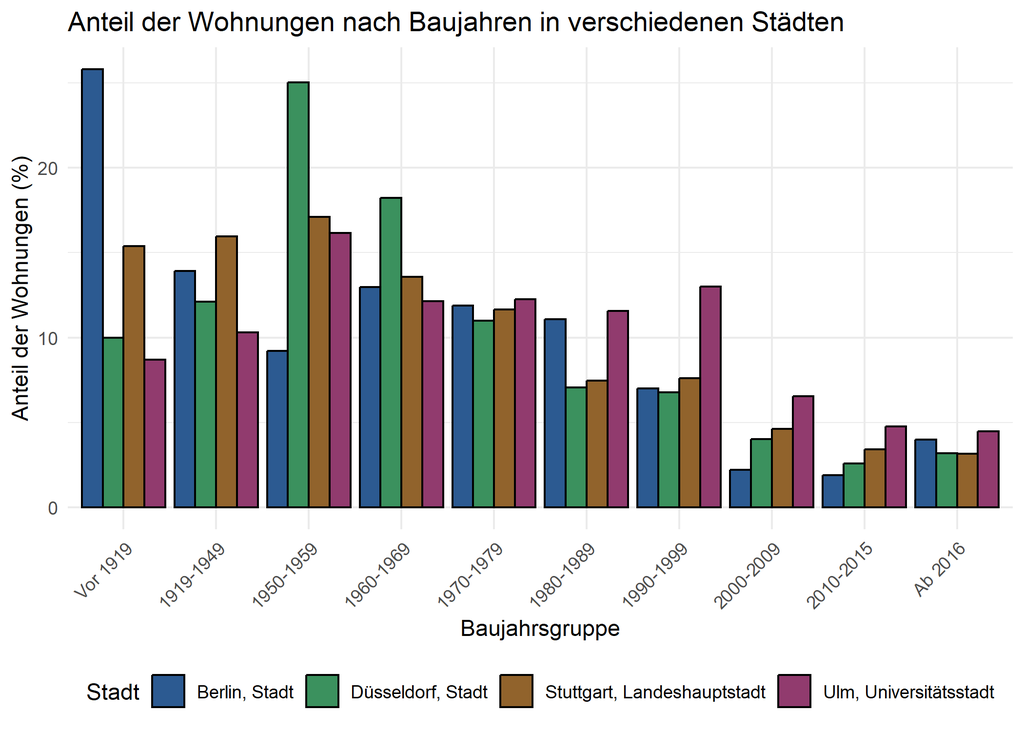

Beschreibung:

Das Balkendiagramm zeigt den Anteil der Wohnungen in verschiedenen Epochen, größtenteils Dekaden, in den vier Städten Berlin, Düsseldorf, Stuttgart und Ulm. Hierbei sind die Baujahrsgruppen auf der X- und der Anteil der Wohnungen auf der Y-Achse. Zur besseren Vergleichbarkeit sind die Balken nach den Baujahrsgruppen gruppiert.

Betrachtet man den Anteil der Wohnungen, die vor 1919 entstanden sind, so fällt auf, dass Berlin mit über 25% mit Abstand am meisten Wohnungen aus dieser Zeit hat. Während Stuttgart mit ca. 15% im Mittelfeld liegt, gibt es in Düsseldorf und Ulm sehr wenig Baubestand von vor 1919. Bei Wohnungen aus der Zeit bis 1949 gibt es in allen Städten bis auf Berlin, wo nur grob 14% der Wohnungen aus dieser Zeit stammen, ein paar Prozentpunkte mehr. Während Berlin in den 50ern noch weiter sinkt, ist bei den anderen drei Städten ein Anstieg zu verzeichnen, insbesondere in Düsseldorf, wo der Anteil der Wohnungen aus dieser Zeit bei ca. 25% liegt. In den 60ern sinkt der Anteil in allen Städten bis auf Berlin, wo er verglichen mit vorher wieder leicht ansteigt. Bei Wohnungen aus den 70ern sind alle 4 Städte ungefähr gleich auf mit ca. 12%. Während der Anteil der Wohnungen aus den 80ern in Düsseldorf und Stuttgart niedriger ausfällt, bleibt er in Berlin und Ulm hoch. In den 90ern hingegen sinkt Berlin auf das Niveau von Düsseldorf und Stuttgart bei ca. 7%, während Ulm sogar leicht ansteigt auf ca. 13%. Erst bei den Wohnungen ab den 2000ern ist auch ein Abstieg in Ulm zu erkennen, jedoch hat Ulm von 1970 an in jeder Epoche bis bis in die Letzte (ab 2016) den höchsten Anteil an Wohnungen aus der jeweiligen Zeit.

Interpretation:

Der erste Ausläufer, Berlin, wo über ein Viertel der Wohnungen vor 1919 gebaut wurden, lässt sich vermutlich damit erklären, dass Berlin bereits im Jahr 1877 eine Millionenstadt wurde und im Jahr 1919 über 1,9 Millionen Einwohner hatte, Ende 1920 waren es durch Bildung der Gemeinde Großberlin sogar 3,9 Millionen ([Quelle](https://de.wikipedia.org/wiki/Einwohnerentwicklung_von_Berlin)). Dass danach weniger gebaut wurde, ist vermutlich auf den Bevölkerungsrückgang nach dem zweiten Weltkrieg zurückzuführen, der erst nach der Wiedervereinigung endete. Der zweite große Ausläufer, Düsseldorf, bei dem ein Viertel der Wohnungen in den 50ern entstanden sind, ist vermutlich darauf zurückzuführen, dass in dieser Zeit das Wirtschaftswunder anlief, zu dem die Kohleförderung im Ruhrgebiet einen beträchtlichen Teil beitrug, wodurch viel Wohnraum benötigt wurde. ([Quelle](https://www.bergbaumuseum.de/forschung/forschungsprojekte/wiederaufstieg-und-niedergang-des-bergbaus-in-der-bundesrepublik)) In Düsseldorf und Stuttgart ist der stetige Rückgang ab den 60ern vermutlich darauf zurückzuführen, dass die Bevölkerung bis in die 90er immer weiter gesunken ist und erst ab den 2000ern wieder leicht gestiegen ist. Ulm ist unter den vier Großstädten ein Ausläufer, da die Stadt erst in den 70ern eine Großstadt wurde, wodurch der Bedarf nach Wohnungen stark angestiegen ist. Zudem ist Ulm relativ gesehen seit 1939 am meisten gewachsen mit einem Bevölkerungszuwachs von ca. 80%.

9. Wie in der vorherigen Aufgabe zu sehen war, unterscheidet sich die Situation in Städten in Bezug auf die jeweiligen Baujahre der Wohnungen deutlich. Es wäre noch spannend zu sehen, ob auch das Alter der Bewohner, die Familienstände, oder die Einwanderungshistorie der Bewohner mit unterschiedlichen Mietpreisen assoziiert sind. Hier sollen Sie in einem ersten generellen Schritt ein paar demografische Faktoren einbeziehen, inwiefern diese eine Auswirkung haben. Betrachten Sie folgende Eigenschaften genauer:
- Familienstand
- Alter der Bewohner
- Einwanderungsgeschichte

Erstellen Sie eine oder mehrere passende Diagramme oder Grafiken für die in Aufgabe 8 aufgeführten Städte.

Beschreiben und interpretieren Sie diese. Haben Sie diese Unterschiede erwartet? Begründen Sie warum oder warum nicht. Wo gibt es Ihrer Ansicht nach besondere Auffälligkeiten? Warum kann es bei der unterschiedlichen Einteilung der Altersgruppen zu Problemen kommen? Was wären Möglichkeiten, um etwaige Probleme zu vermeiden?

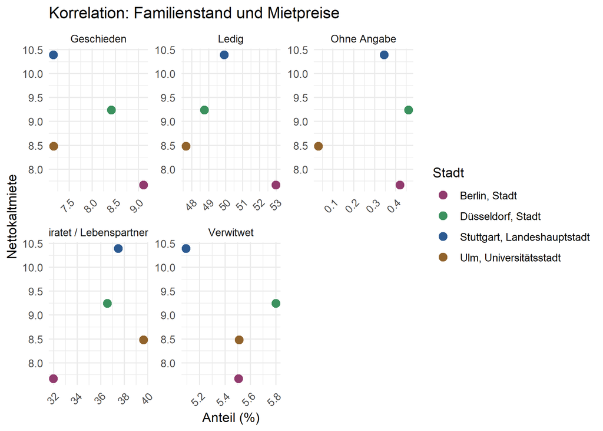

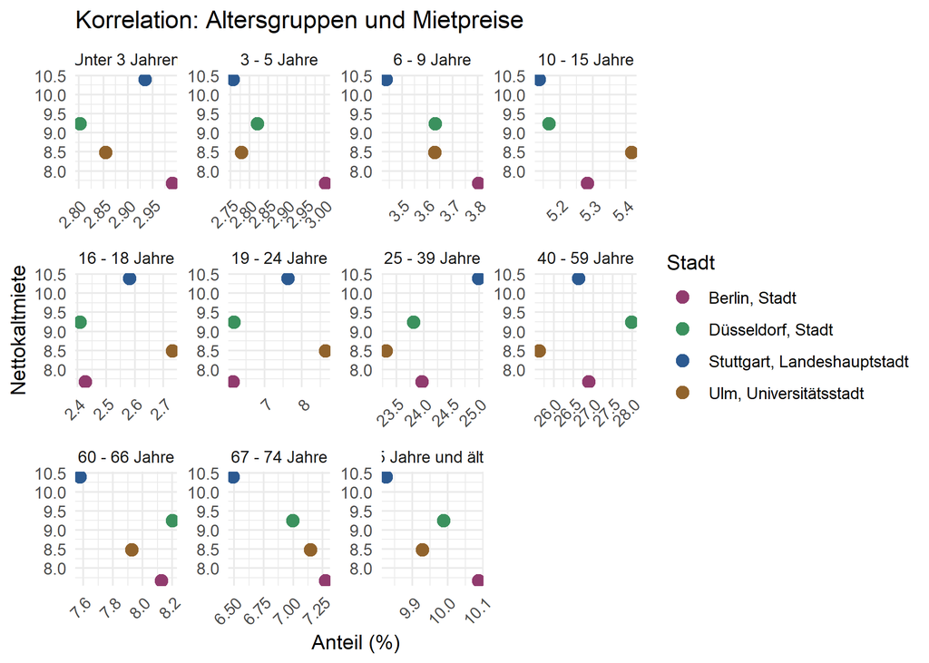

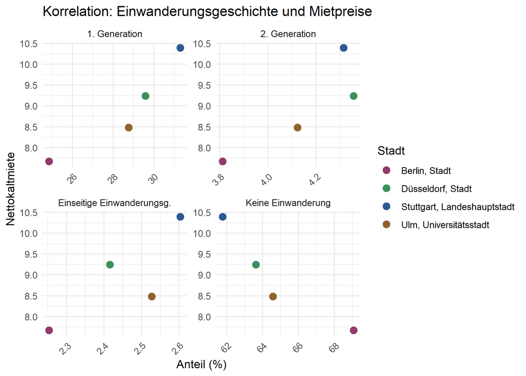

Beschreibung:

Die drei Diagramme visualisieren Korrelationen zwischen der Nettokaltmiete pro Quadratmeter und bestimmten soziodemografischen Merkmalen in vier deutschen Städten: Berlin, Düsseldorf, Stuttgart und Ulm. Das erste Diagramm zeigt den Zusammenhang zwischen dem Familienstand (geschieden, ledig, ohne Angabe, verheiratet/ Lebenspartner, verwitwet) und den Mietpreisen. Das zweite Diagramm untersucht die Verteilung der Altersgruppen von „unter 3 Jahren“ bis „75 Jahre und älter“ in den vier Städten und ihre Beziehung zu den Mietpreisen. Schließlich befasst sich das dritte Diagramm mit der Einwanderungsgeschichte (1. Generation, 2. Generation, keine Einwanderung, einseitige Einwanderungsgeschichte) und deren Korrelation zu den Mietpreisen. Die Punkte repräsentieren in allen drei Dokumenten die jeweiligen Städte, und die X-Achse zeigt den prozentualen Anteil der jeweiligen Gruppe in der Bevölkerung, während die Y-Achse die Mietpreise wiedergibt. In allen Diagrammen lassen sich Unterschiede zwischen den Städten erkennen, die farblich kodiert dargestellt sind.

Interpretation:

Die Daten legen nahe, dass der Familienstand einen gewissen Einfluss auf die Mietpreise hat. Dies könnte darauf hinweisen, dass diese Gruppen bestimmte Wohnformen bevorzugen, die teurer sind, wie z. B. kleinere Wohnungen für geschiedene Personen oder größere Wohnungen für Familien. Düsseldorf und Ulm scheinen hier weniger ausgeprägte Muster aufzuweisen, was möglicherweise auf eine gleichmäßigere Verteilung der Wohnungsbedarfe hindeutet.

Das zweite Diagramm, das die Altersgruppen betrachtet, zeigt deutliche Unterschiede. Jüngere Altersgruppen (z. B. unter 3 Jahren und 3–5 Jahre) sind in Städten wie Ulm und Berlin mit niedrigeren Mietpreisen assoziiert. Dies könnte darauf hindeuten, dass junge Familien, die in diese Alterskategorien fallen, eher in günstigeren Gemeinden wohnen wohnen. In Ulm und Düsseldorf bleiben die Mietpreise über die meisten Altersgruppen hinweg relativ moderat. Interessant ist, dass die älteren Altersgruppen (z. B. 60–66 Jahre und darüber) in den meisten Städten mit niedrigeren Mietpreisen verknüpft sind, was möglicherweise auf eine höhere Eigenheimquote oder eine geringere Nachfrage nach zentral gelegenen Mietwohnungen bei diesen Gruppen hinweist. Zudem könnte dies damit zusammenhängen, dass in kleineren Städten der Altersdurchschnitt meist höher und die Mieten meist niedriger sind.

Beim dritten Diagramm, das sich mit der Einwanderungsgeschichte befasst, fällt eine leichte Korrelation auf. So gibt es in diesen 4 Städten eine positive Korrelation zwischen Einwanderung und Nettokaltmiete, egal ob in 1. Generation, 2. Generation oder bei einer einseitigen Einwanderungsgeschichte. Beim Anteil an Einwohnern, die in erster Generation eingewandert sind ist der Effekt jedoch am stärksten zu erkennen. Somit gibt es eine negative Korrelation zwischen der Nettokaltmiete und dem Anteil an Einwohnern ohne Einwanderung in den letzten beiden Generationen. Dies könnte daran liegen, dass der Anteil an Menschen mit Migrationsgeschichte in größeren Städten aus diversen Gründen meist größer ist.

Die Ergebnisse entsprechen in Teilen den Erwartungen. Es ist nachvollziehbar, dass der Familienstand oder die Altersgruppen Unterschiede im Mietpreis bedingen, da diese Merkmale oft mit spezifischen Wohnbedürfnissen verbunden sind. Beispielsweise sind geschiedene Personen und junge Familien oft auf kleinere Wohnungen angewiesen, die in Ballungsräumen teuer sind. Überrascht hat die Korrelation bei der Einwanderungsgeschichte.

Probleme bei der Einteilung und Lösungsvorschläge: Ein potenzielles Problem in der Analyse liegt in der unterschiedlichen Einteilung der Altersgruppen. Kleine Intervalle wie „3–5 Jahre“ werden detailliert betrachtet, während größere Gruppen wie „40–59 Jahre“ zusammengefasst werden. Diese Uneinheitlichkeit erschwert die Interpretation, da sie Gruppen mit sehr unterschiedlichen Wohnbedürfnissen zusammenfasst. Einheitlichere Intervalle, z. B. alle 10 Jahre, würden eine klarere Analyse ermöglichen.

Zusätzlich könnten weitere Faktoren wie Einkommen, Bildungsstand oder Beruf berücksichtigt werden, um eine differenziertere Interpretation zu ermöglichen. Auch die geografische Verteilung innerhalb der Städte könnte einbezogen werden, da Mietpreise in zentralen und peripheren Stadtteilen stark variieren können. Solche Erweiterungen könnten helfen, die Dynamik zwischen den untersuchten Variablen und den Mietpreisen besser zu verstehen.

In den bisherigen Analysen wurden demografische und wohnungsbezogene Faktoren in verschiedenen Städten Deutschlands untersucht. Dabei lag der Fokus darauf, wie diese Merkmale in unterschiedlichen Regionen das Mietpreisniveau und dessen Struktur beeinflussen. Aufbauend auf diesen Erkenntnissen soll der Blick nun gezielt auf den Vergleich zwischen Ost- und Westdeutschland gelenkt werden. Diese regionale Differenzierung ermöglicht es, potenzielle Unterschiede und Gemeinsamkeiten zwischen den beiden Landesteilen genauer zu analysieren. Insbesondere wird betrachtet, wie sich die Mietpreisstruktur in Ost- und Westdeutschland darstellt und ob sich hierbei spezifische Muster oder Abweichungen erkennen lassen.

10. Betrachten Sie nun die Städte `Dresden, Stadt`, `Chemnitz, Stadt`, `Stuttgart, Landeshauptstadt`, `Ulm, Universitätsstadt`,`Düsseldorf, Stadt`und `Berlin, Stadt`. Vergleichen Sie in einem ersten Schritt die Anzahl an Einwohnern, den Anteil an Menschen, die deutscher Herkunft sind, den Anteil an neuen und alten Wohnungen, sowie die durchschnittlichen Mietpreise. Erweitern Sie ihre Analyse um die durschnittlichen Wohnflächen.

Erstellen Sie für die genannten Städte eine deskriptive Tabelle. Beschreiben und interpretieren Sie diese. Beantworten Sie insbesondere folgende Fragen:

- In wie weit könnte das Alter der Wohnungen eine Rolle für den Mietpreis spielen?
- Gibt es Auffälligkeiten zwischen den einzelnen Städten in Bezug auf Herkunft der Bewohner, Einwohner und Größe der Wohnungen?
- Warum könnte es problematisch sein, wenn Sie die Städte als ein Ganzes betrachten?
- Sind Ihre Ergebnisse auf die ganze Stadt verallgemeinerbar?
- Was sind ihrer Meinung nach Faktoren, die die unterschiedlichen Mietpreise in Ost und West erklären?
- Welche Maßnahmen wären geeignet, um in Düsseldorf, Ulm und Stuttgart die Mietpreisstruktur anzupassen und bezahlbaren Wohnraum zu schaffen?

|  | Name_Gemeinde | Anzahl_Einwohner | Anteil_Deutscher | Anteil_Alte_Wohnungen_vor_2000 | Anteil_Neue_Wohnungen_ab_2000 | Durchschnitt_Wohnfläche | Durchschnitt_Mietpreise |
| --- | --- | --- | --- | --- | --- | --- | --- |
| 1 | Berlin, Stadt | 3596999 | 0.8045656949028899 | 0.9186162282113898 | 0.08138377178861024 | 62.85429396799734 | 482.0924347345396 |
| 2 | Chemnitz, Stadt | 240078 | 0.9023025849932106 | 0.9344066903727117 | 0.0655933096272883 | 61.20154885613813 | 321.9201469832866 |
| 3 | Dresden, Stadt | 557782 | 0.9069277961640928 | 0.9002084206968637 | 0.09979157930313633 | 61.43628323845945 | 425.1390800101393 |
| 4 | Düsseldorf, Stadt | 611258 | 0.772411976612167 | 0.9019862472969417 | 0.09801375270305832 | 67.51185633949463 | 623.8095525769304 |
| 5 | Stuttgart, Landeshauptstadt | 610458 | 0.7430011565087197 | 0.8878785565711886 | 0.1121214434288113 | 69.36834304942006 | 720.7370842834745 |
| 6 | Ulm, Universitätsstadt | 127116 | 0.7822304037257308 | 0.8418235138951387 | 0.1581764861048613 | 76.36025133814289 | 647.5349313474517 |

Beschreibung: Die Tabelle besteht aus sechs Zeilen und umfasst sieben Spalten, welche den Namen der Gemeinde, Anzahl der Einwohner, den Anteil an Menschen, die deutscher Herkunft sind, den Anteil an neuen und alten Wohnungen, durchschnittliche Mietpreise und die durchschnittliche Wohnfläche enthalten. In dieser Tabelle werden die Gemeinden “Dresden, Stadt”, “Chemnitz, Stadt”, “Stuttgart, Landeshauptstadt”,“Ulm, Universitätsstadt”, “Düsseldorf, Stadt” und “Berlin, Stadt” und die dazugehörigen, oben genannten ,Daten analysiert.

Interpretation + Detaillierte Beschreibung: Auffällig ist zunächst, dass der Anteil an Personen mit deutscher Herkunft unterschiedlich hoch ist. So haben Chemnitz und Dresden einen nahezu identischen Anteil mit den Werten 0.902 und 0.906. Dagegen haben die Städte Düsseldorf, Stuttgart und Ulm auch ähnliche Werte mit 0.77 , 0.74 und 0.78 . Nur Berlin ist etwas in der Mitte mit 0.804. Dadurch wird auffällig, dass Städte aus dem Osten eher einen hohen Anteil an Personen mit deutscher Herkunft haben, wie Städte aus dem Westen.

Zusätzlich ist ein ähnliches Muster bei der Wohnungsgröße zu erkennen. Dort, wo der Anteil an Personen mit deutscher Herkunft geringer ist, ist auch die durchschnittliche Wohnfläche höher.

Ebenfalls auffällig ist, dass alle Städte einen sehr hohen Anteil an Wohnungen haben, die vor dem Jahr 2000 gebaut wurden und somit als alte Wohnungen zählen. Der Wert liegt dabei bei allen zwischen 0.84 und 0.935. Das könnte ebenfalls einen Einfluss auf die Mietpreise haben, denn in Chemnitz, wo der höchste Anteil an alten Wohnungen ist, ist die Miete auch am niedrigsten und in Ulm, wo es auch am meisten neue Wohnungen gibt, ist die Miete auch relativ hoch. Allerdings kann das nicht zuverlässig anhand dieser Daten bewiesen werden, da die Mietpreise von verschiedenen anderen Faktoren abhängen. Jedoch macht es Sinn, dass dort, wo mehr neue Wohnungen gebaut wurden, auch die Miete generell höher ist. Das liegt daran, dass neu gebaute Wohnungen prinzipiell in einem deutlich besseren Zustand sind, als ältere Wohnungen. Dadurch ist auch die Miete für diese höher, was die durchschnittliche Miete steigen lässt.

Doch auch wenn man die Städte so untereinander ganz gut oberflächlich vergleichen kann, so sind die Daten aus der Tabelle trotzdem nur ein Durchschnitt der ganzen Stadt und ist somit nicht verallgemeinerbar oder zutreffend auf jeden Stadtteil.

Um nun aber noch kurz zu den Mietpreisen zurückzukommen. Dieser klare Unterschied zwischen Ost und West ist meiner Meinung nach auf die Attraktivität des Standortes, gerade wenn es um Jobs geht, zurückzuführen. Nach dem Zusammenbruch der DDR war die Wirtschaft im Osten sehr schwach, gerade im Vergleich zum Westen. Dadurch sind sehr viele Personen nach der Wiedervereinigung in den Westen gegangen, um bessere Jobs zu finden. Auch wenn die wirtschaftliche Situation im Osten wieder deutlich besser ist, gibt es immer noch nicht so viele große Firmen im Osten wie im Westen, welche als begehrte Arbeitgeber fungieren. Dadurch gibt es keine so große Nachfrage nach Wohnraum im Osten wie im Westen, weshalb die Mieten deutlich niedriger sind.

Um den Wohnraum in den Städten Düsseldorf, Ulm und Stuttgart bezahlbarer zu machen, könnte eine Mietendeckelung sinnvoll sein, damit die Mietpreise nicht weiter so stark steigen. Außerdem ist der Bau von Sozialwohnungen ein weiterer effektiver Weg, um bezahlbaren Wohnraum zu schaffen. Außerdem könnten leerstehende Bürogebäude als Wohnungen umgebaut werden, was billiger und effizienter ist. Und das sind nur einzelne Beispiele, um für mehr bezahlbaren Wohnraum zu sorgen.

11. Lesen Sie den [folgenden Artikel](https://www.tagesschau.de/wirtschaft/sozialwohnungen-bau-mangel-101.html). Dort werden Sozialwohnungen thematisiert, warum so viele fehlen und wer davon vor allem betroffen ist. Beantworten Sie anschließend folgende Fragen:
- Welche Bevölkerungsgruppen sind am stärksten von der Sozialwohnungsnot betroffen und inwiefern?
- Was sind Gründe, warum es zu wenige Sozialwohnungen gibt?
- Wie sieht die historische Entwicklung des Sozialwohnungsbaus aus, im Hinblick auf Vorhandensein von Wohnungen und Investitionen in den Bau von neuen Wohnungen?
- Welche Anreize könnten Investoren motivieren, mehr Sozialwohnungen zu bauen?
- Welche innovativen Ansätze können Bauherren verfolgen, um die Kosten für den Wohnungsbau zu senken?

Die ärmste Bevölkerungsschicht ist am stärksten betroffen,da durch die Wohnungsknappheit die Mieten immer weiter steigen und sie nicht die Mittel haben, um sich dann noch eine Wohnung zu leisten.

Gründe für den Mangel an Sozialwohnungen sind vor allem die Steigenden Preise für einen Neubau, hohe Darlehenszinsen und der Fachkräftemangel bei den Baufirmen.Diese Faktoren sorgen dafür, dass kaum Anreize für Investoren besteht, momentan in diesen Sektor zu investieren.

In den 90er Jahren gab es noch rund drei Millionen Sozialwohnungen, wobei es 2023 nur noch 1,1 Millionen sind. Im Jahre 2022 sollten nach der Regierung 100.000 neue Sozialwohnungen gebaut werden, allerdings waren es am Ende sogar 27.000 weniger Sozialwohnungen als im Vorjahr. Das beschreibt einen klaren Trend über die letzten Jahrzehnte, dass es immer weniger Sozialwohnungen gibt, obwohl immer mehr benötigt werden.

Mögliche Anreize für Investoren währen Steuervorteile, Förderungen vom Staat , sowie weniger Auflagen und schnellere Genehmigungen. Dadurch würde das Bauen deutlich billiger und rentabler für die Investoren werden, sowie den Prozess der Bauens beschleunigen.

Die Bauherren könnten kleiner und materialsparender bauen. Was ist damit gemeint? Sie könnten die Treppenhäuser kleiner machen, Wandstärke verringern und beispielsweise auf Holzbau umsteigen. Das sind nur einzelne Beispiele, wie sie Material und Kosten sparen können.

12. Gerade die Politik ist gefordert, bezahlbaren Wohnraum zu realisieren. Dabei gibt es eine Viezahl an politischen Maßnahmen, die aufgestellt wurden und umfangreich diskutiert werden. Betrachten Sie die folgenden Maßnahmen, welche helfen sollen, die angespannte Lage auf dem Mietmarkt zu entlasten. Argumentieren Sie, warum diese Maßnahmen sinnvoll/nicht sinnvoll sind und in welcher Art und Weise diese umgesetzt werden können.
1. “Fachleute fordern, die Regulierung von Bestandsmieten zu lockern, damit sich ihr Niveau den Neuvertragsmieten annähert, mehr Menschen umziehen und sich Wohnraum besser verteilt.”
2. “Eine weitere Möglichkeit wäre, Mieterhöhungen bei Neuvertragsmieten zu begrenzen.”
3. “Am einfachsten ist es, wenn vor allem in Großstädten, wo bezahlbarer Wohnraum fehlt, mehr gebaut wird.”
4. “Am besten wäre es, wenn zukünftig mehr Vermieter in regelmäßigen Abständen die Miete anpassen.”

1.) Diese Maßnahme wäre nicht sinnvoll, da die Neuvertragsmieten häufig teurer als die Bestandsmieten sind, was dafür sorgen würde, dass die Mietpreise noch teurer werden und die Mieter noch mehr belastet werden. Zudem ist es wenig sinnvoll den Wohnraum auf diese Art mehr zu verteilen, da Mieter gezwungen werden ihren Wohnraum aufgrund der Mietänderungen zu verlassen und somit in Gegenden ziehen müssen, wo der Wohnraum billiger ist, allerdings der Weg zur Arbeit auch deutlich länger ist. Zudem würde diese Maßnahme dazu führen, dass dort wo der Wohnraum sehr gefragt ist, nur wohlhabende Mieter leben können und einkommensschwache Mieter immer weiter aus diesen gegenden verdrängt werden.Das würde dann auch noch die einkommensschwachen Mieter weiter belasten, da diese dann nur den Nachteil tragen, dass sie einen weiten Arbeitsweg haben. Sollte man diese Maßnahme trotzdem umsetzen wollen, so wäre eine kontrollierte und langsame Anpassung der Bestandsmieten wichtig, um eine plötzliche starke Belastung der Mieter zu verhindern.Zudem könnte man bestimmte Bedingungen für die Erhöhung der Bestandsmiete festlegen, damit Senioren oder einkommensschwache Familien davon nicht oder nur leicht betroffen werden.

2.) Mieterhöhungen bei der Neuvermietung zu begrenzen ist an sich Sinnvoll, da somit ein rapider Anstieg der Mietpreise verhindert wird, was vermehrt bezahlbaren Wohnraum zur Folge hat. Allerdings muss man hierbei aufpassen, denn wenn man die Mieterhöhungen bei Neuvermietungen zu sehr beschränkt, dann könnten sich Investitionen für Investoren plötzlich nicht mehr lohnen, wodurch weniger Wohnungen gebaut werden. Das hätte dann genau den gegenteiligen Effekt, den man eigentlich haben will, da so kein neuer Wohnraum geschaffen wird. Zudem könnte das dazu führen, dass die bestehenden Wohnungen vernachlässigt werden, da Sanierungen sich durch die Begrenzung der Mieterhöhung sich plötzlich nicht mehr lohnen. Somit müsste man einen festgesetzten Betrag finden, bei dem sich Investitionen weiterhin lohnen, aber die Mietpreise nicht durch die Decke gehen.

3.) Das ist sinnvoll, allerdings gibt es da einige Probleme, wie dass genau dort der Boden zum Bauen sehr begrenzt und teuer ist, was die Idee für Investoren zunehmend unattraktiv macht. Wenn man das umsetzen will, braucht man erhebliche Förderungen für diese Projekt und zudem müssen die Kosten für das Bauen reduziert werden.Zudem ist genau in den Großstädten der Wohnraum sehr beliebt und das Bauen sehr teuer, weshalb es fraglich ist, ob so wirklich bezahlbarer Wohnraum geschaffen wird. Somit ist die Idee in der Theorie sinnvoll, aber in der Praxis könnte das anders aussehen. Eine Möglichkeit, um bezahlbaren Wohnraum in den Großstädten zu schaffen, wären Projekt, um ungenutzten bestehenden Raum von zum Beispiel leerstehenden Firmengebäuden zu Wohnraum umzubauen. Das würde weniger Kosten verursachen, würde schnell gehen und wäre somit auch vermutlich bezahlbarer.

4.)Diese Aussage hat mehrere Seiten. Einerseits wäre diese Maßnahme nicht sinnvoll, da sich so die Mieten vermutlich immer weiter erhöhen würden, was bezahlbaren Wohnraum verringert. Andererseits würden sich die Mieten immer regelmäßig erhöhen und nicht schlagartig. So könnten sich die Mieter besser darauf einstellen und würden durch plötzliche starke Mieterhöhungen nicht mehr überrascht werden, was sie zum Ausziehen zwingen könnte.

# Einzelne Stadtteile in Deutschland

In allen vorherigen Aufgaben haben Sie die Städte, Gemeinden oder auch Landkreise immer als ein Ganzes betrachtet. Jedoch ist es schwierig gerade in Großstädten wie Berlin, Düsseldorf oder auch Stuttgart allgemeine Aussagen über die Mietsituation auf Stadtebene zu treffen. Dies liegt unter anderem daran, dass unterschiedliche Stadtviertel unterschiedliche demografische Eigenschaften, sowie eine unterschiedliche Mietstruktur aufweisen können. Hier wäre es sinnvoll sich mit dem Stadtbild und der Verteilung der Mieten genauer auseinanderzusetzen, um zu sehen, wie sich Mieten innerhalb der Stadt verteilen. Wie in Aufgabe 10 zu sehen war, weisen die Städte im Westen Deutschlands untereinander, sowie die Städte im Osten ähnliche Merkmale auf, weshalb Sie sich in den folgenden Aufgaben auf je eine große und eine kleinere Stadt aus beiden Regionen konzentrieren.

13. In dieser Aufgabe sollen Sie ihren Datensatz aus Aufgabe 4, bei dem Sie Kartendaten und Informationen zu Mieten und LEQ auf 1km-Gitterebene heruntergeladen und zusammengefügt haben, verwenden und vier Karten zeichnen, welche die Verteilung der Nettokaltmieten in den Stadtteilen der Städte “Stuttgart, Landeshauptstadt”, “Ulm, Universitätsstadt”, “Chemnitz, Stadt” und “Dresden, Stadt” anschaulich visualisieren.

Erstellen Sie vier Grafiken, beschreiben und interpretieren diese. Gehen Sie insbesondere auf folgende Fragen ein:

- Welche Besonderheiten fallen Ihnen bei diesen Städten auf?
- Gibt es eine Segregation in Bezug auf die Mieten in einzelnen Stadtteilen?
- Falls es eine Segregation gibt, welche Konsequenzen könnte dies haben?
- Welche Rolle spielen geografische oder infrastrukturelle Faktoren bei den Mietpreisen?
- Gibt es Unterschiede zwischen Städten im Osten und Westen Deutschlands, falls ja, welche Einflüsse in Bezug auf Wirtschaft und Arbeitsmarkt könnte dies in den jeweiligen Städten haben?

*Hinweis:* Wenn Sie einheitliche Legenden für die Karten haben möchten und die vier Städte nebeneinander oder untereinander darstellen wollen, so empfiehlt sich das Paket `ggpubr` und dort der Befehl `ggarrange`.

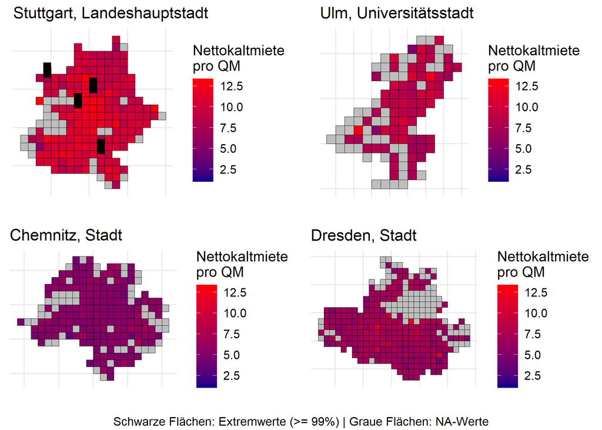

Beschreibung/ vereinzelte Erklärung der Grafiken: Es sind 4 Grafiken zu erkennen und die Farbskala ist mit dunkelblau für niedrige und rote für hohe Werte gewählt.Dabei werden sehr hohe Werte shwarz eingefärbt und NA-Werte grau. Eingefärbt wird dabei nach dem Betrag der Nettokaltmiete pro Quadratmeter Wohnfläche.Alle grauen Flächen, die zu der jeweiligen Stadt gehören, entstehen dadurch, da für diese Stadtteile keine Daten vorliegen. Das folgt möglicherweise daraus, dass in diesen Stadtteilen beispielsweise Waldfläche, Felder, Parks oder Firmenstandorte sind und somit dort gar keine Wohnungen existieren, zu denen es Daten geben könnte.

Auffällig ist in dieser Grafik, dass Stuttgart sehr hell eingefärbt ist, bis auf kleine Stadtteile, wo die Färbung sogar schwarz ist. Das ist nicht sehr überraschend, da in einer Großstadt wie Stuttgart oft mit sehr hohen Mieten zu rechnen ist, was sich hier auch nochmal bestätigt.

In Ulm ist hingegen alles zwar heller, aber nicht annähernd so wie Stuttgart. Zudem gibt es auch dort keine extremen Werte. Insgesamt ist Ulm sehr durchwachsen zwischen leicht dunkel und hell.

Chemnitz ist im Vergleich einheitlich dunkel gefärbt.Zwar gibt es vereinzelte leicht helle Stadtteile, aber auf das gesamte Bild der Stadt haben diese nur einen geringen Einfluss. Dresden ist da sehr ähnlich, nur dass dort die Mieten generell etwas höher sind. So erscheint die Stadt auf der Grafik ähnlich, aber etwas heller. Zudem gibt es in Dresden kleine Stadtteile, die sogar wirklich hell sind.

Interpretation: Aus den Grafiken lässt sich erkennen, dass es sehr wohl eine Segregation in einzelnen Stadtteilen in Bezug auf die Mieten gibt. Das ist sehr auffällig in Stuttgart zu erkennen. Das ist zu erkennen, da die Stadtmitte deutlich heller als die umliegenden Stadtteile ist. Zudem hat Stuttgart auch die schwarzen Extreme, die vermehrt in der Mitte der Stadt liegen, aber auch teilweise außerhalb. Dabei ist das Extremum am nördlichen Rand Stuttgarts am höchsten. In Ulm ist die Farbvariation ebenfalls gegeben, was für Segregation spricht. Chemnitz und Dresden haben dagegen eine ziemlich einheitliche Färbung, was dort gegen Segregation spricht, allerdings gibt es in vereinzelten Stadtteilen auch dort sehr wohl bemerkbare Farbunterschiede. Allerdings sind diese viel geringer im Vergleich zu Stuttgart oder Ulm. Ein Ort wo solch eine Segregation in Dresten zumindist auffällt ist unten rechts in der Grafik. Dort ist ein heller Stadtteil direkt neben einem dunklen Stadtteil, was sonst in der Grafik von Dresden nur selten auftaucht.

Die bestehende Segregation bedeutet, dass in der Innenstadt oder an beliebten Standorten nur noch sehr gut verdienende Haushalte wohnen können und schlecht verdienende Haushalte werden dazu gezwungen, weiter außerhalb dieser Stadtteile zu wohnen. Das führt dazu, dass ärmere Haushalte immer weiter aus der Innenstadt oder von beliebten Standorten verdrängt werden. Dadurch sind sie gegebenenfalls weiter weg von wichtigen Bahn- , Bus- oder Zugverbindungen, sowie unter Umständen von ihrem Arbeitsplatz und dem öffentlichen Leben generell. Das hat einen längeren Arbeitsweg oder eine geringere Teilhabe am öffentlichen Leben zur Folge. Dabei ist es kein Zufall, dass diese Personen schlechte Bahn-, Bus- oder Zugverbindungen haben oder weiter weg von wichtigen und beliebten Standorten sind. Denn genau dort, wo beispielsweise eine sehr gute Bahnverbindung besteht oder Attraktionen sind, ist der Wohnraum sehr gefragt, was die Preise steigen lassen kann. Somit haben geographische und infrastrukturelle Faktoren einen sehr großen Einfluss auf die Mietpreise, da so der Wohnraum gegebenenfalls deutlich attraktiver wird.

Ein Beispiel dafür ist die oben erwähnte Ecke in Dresden. Dort um Attraktionen wie “Schloss und Park Pillnitz”, “Kamelienhaus Pillnitz” oder “Ruine Pillnitz” sind die Mieten hoch. Wenn man jetzt aber ein bisschen weiter Richtung Süden geht, ist dort der dunkle Fleck zu finden, wo die Mietpreise deutlich geringer sind. Obwohl die Entfernung von den Attraktionen auch nicht weit weg ist, so sind die Häuser nicht direkt bei denen und somit sind die Mieten billiger. Andererseits ist dort eine Ausbildungsstätte, was darauf hindeuten könnte, dass da möglicherweise Studentenwohnungen oder ähnliches sind, was zu geringeren Preisen führt. An diesem konkreten Beispiel aus der Grafik sieht man, was für einen Einfluss die Umgebung auf die Mietpreise haben kann. Selbst in Städten, wo es kaum große erkennbare Mietunterschiede gibt.

Zum Schluss analysieren wir noch kurz, ob es einen erkennbaren Unterschied zwischen den Städten aus dem Westen, hier Stuttgart und Ulm, und Städten aus dem Osten, hier Dresden und Chemnitz, gibt. Um das kurz auszudrücken, ja es gibt einen deutlichen Unterschied. Während Stuttgart und Ulm eher heller und durchwachsen gefärbt sind, sind Dresden und Chemnitz dunkel und deutlich kontinuierlicher gefärbt.

14. Nachdem Sie in Aufgabe 13 die Verteilung der Mieten der einzelnen Stadtteile visualisiert haben, sollten Sie in dieser Aufgabe den Anteil der Leerstandsquoten in den Stadtteilen der Städte “Stuttgart, Landeshauptstadt”, “Ulm, Universitätsstadt”, “Chemnitz, Stadt” und “Dresden, Stadt” veranschaulichen.

Erstellen Sie vier Grafiken, beschreiben und interpretieren diese. Gehen Sie insbesondere auf folgende Fragen ein:

- Was könnten Gründe sein, dass die Leerstandsquote in bestimmten Stadtteilen höher ist, als in anderen?
- Welche Besonderheiten fallen Ihnen bei diesen Städten auf? Auch im Hinblick auf ihre Erkenntnisse aus Aufgabe 13.
- Vergleichen Sie die Grafiken aus Aufgabe 13 und Aufgabe 14. Was könnte der Grund für die unterschiedlichen Muster sein?
- Welche Maßnahmen ergreifen Städte mit hohen Leerstandsquoten, um diese zu reduzieren?

*Hinweis:* Wenn Sie einheitliche Legenden für die Karten haben möchten und die vier Städte nebeneinander oder untereinander darstellen möchten, so empfiehlt sich das Paket `ggpubr` und dort der Befehl `ggarrange`.

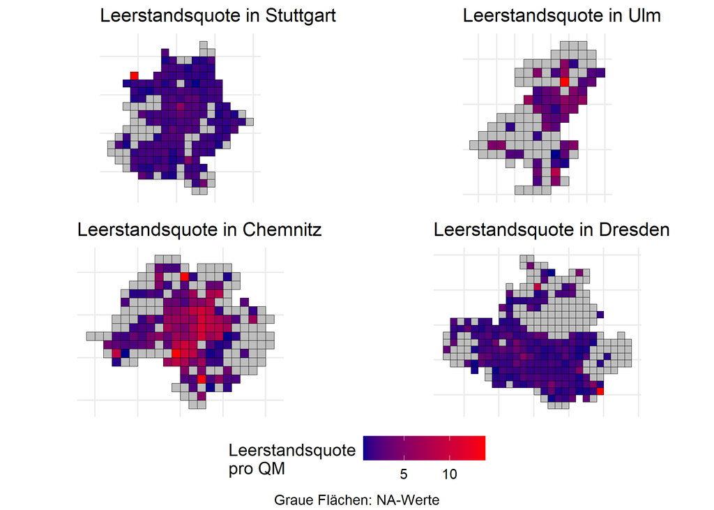

Beschreibung: Es sind vier Grafiken zu sehen, die die Leerstandsquote in Chemnitz, Dresden, Ulm und Stuttgart abbilden. Die Grafiken sind nach der Leerstandsquote eingefärbt, wobei dunkelblau eine sehr geringe Leerstandsquote beschreibt und rot eine sehr hohe Leerstandsquote. Grau bedeutet, dass für die Stadtteile keine Daten vorliegen. Was auffällig ist, dass die Stadtteile, bei denen keine Daten vorhanden sind, sich teilweise geändert haben. Die Ursache dafür ist schwer zu sagen, bedeutet aber, die Annahme, dass es sich vermutlich um Waldflächen, Bürogebäude oder Ähnliches handelt, ist nicht zu 100% richtig. Vermutlich liegen dort einfach teilweise keine Daten vor.

Beschreibung im Detail + teilweise Interpretation:

In der Grafik von Stuttgart ist zu sehen, dass Stuttgart fast überall eine sehr geringe Leerstandsquote hat. Nur da, wo die Nettokaltmiete sehr hoch ist, ist auch die Leerstandsquote vergleichsweise hoch. So ist das Extremum der letzten Grafik hier auch sehr hell gefärbt, aber auch die Innenstadt ist zumindest vergleichsweise etwas heller gefärbt, wie die äußeren Stadtteile. Das ist aber nur ein kleiner Unterschied. Das könnte daran liegen, dass die Preise für viele Personen viel zu hoch sind und man deshalb auch schwer einen Mieter findet.Dass der Rest dunkel ist, macht auch Sinn, da die Mietpreise im Rest etwas geringer im vergleich zum Extremum sind und viele Personen auch nach Stuttgart ziehen wollen. Das erklärt die geringe Leerstandsquote.

Bei den anderen drei Grafiken ist so ein direkter Bezug allerdings nicht zu erkennen. In Ulm besteht generell eine halbwegs geringe Leerstandsquote, mit der Ausnahme von einem Stadtteil im Norden von Ulm, der sehr rot ist.Die Färbung ist deutlich dunkler im Vergleich zu der Grafik in Aufgabe 13. Das könnte darauf hinweisen, dass viele Personen Interesse haben, nach Ulm zu ziehen und da die Mietpreise nicht sehr hoch, sondern eher im Mittelfeld sind, können sich die Personen das auch leisten.

Der Stadtkern in Chemnitz ist besonders auffällig, da dieser relativ hell rot im Vergleich ist.Der Rand ist dagegen eher dunkler. Wie in der Grafik aus Aufgabe 13 zu sehen ist, sind die Mietpreise in Chemnitz auch relativ niedrig, was dafür spricht, dass nicht viele Personen Interesse haben, nach Chemnitz zu ziehen. Deshalb ist die Leerstandsquote ziemlich hoch.

Dresden ist ähnlich wie Stuttgart sehr dunkel, mit einer Ausnahme im Südosten von Dresden. Das ist überraschend , da die Preisunterschiede im Vergleich zu Chemnitz nicht sehr groß sind, was die Mieten angeht. Das deutet darauf hin, dass eine sehr hohe Nachfrage nach Wohnraum in Dresden besteht.

Interpretation:

Dass die Leerstandsquote von manchen Stadtteilen variiert, könnte mit schlechten Bus-, Bahnverbindungen oder der generellen weiten Entfernung von wichtigen Dreh- und Angelpunkten zu tun haben. Eine andere Möglichkeit ist die viel zu hohe Miete, welche in den Stadtteilen gefordert wird, obwohl es nicht genug Personen gibt, die sich sowas leisten können oder wollen .

Die Unterschiedliche Musterung bei einigen Grafiken im Vergleich zu Aufgabe 13, könnte daher kommen, dass es noch andere Faktoren wie Mietpreise und Leerstandsquote gibt. Die geographische und infrastrukturelle Lage der Stadtteils spielt auch eine sehr große Rolle dabei, wie hoch die Nachfrage für Wohnungen in diesem Stadtteil ist. Gerade das und zu hohe Preise für eine Wohnung in solchen Stadtteilen führt dazu, dass viele Wohnungen leer stehen. Da könnte tatsächlich auch der Unterschied zwischen Ost- und Westdeutschland eine wichtige Rolle spielen, was aber anhand dieser Grafiken nicht belegbar ist. Das liegt daran, dass Chemnitz und Dresden sich hierbei stark unterscheiden, wodurch kein wirkliches Muster entsteht.

Mögliche Maßnahmen, um die Leerstandsquote zu reduzieren, sind, die Preise entweder zu senken oder die Lage attraktiver zu machen.Dresden ist dafür ein perfektes Beispiel. Dresden hat ein reiches Kulturerbe und hat sich mit Universitäten und Instituten gerade im Bereich der Mikroelektronik etabliert und ist somit einer der attraktivsten Orte im Osten Deutschlands. Wie man an diesem Beispiel sehen kann, ist es sehr hilfreich zu versuchen, in Sektoren wie Universitäten oder auch in der Industrie gut aufgestellt zu sein, damit die Stadt für Außenstehende attraktiv ist.

15. Die aktuellen Mietpreise und deren Entwicklungen hindern in Deutschland immer mehr Menschen daran, dass sie sich eine neue geeignete Wohnung suchen. Personen, die aufgrund ihrer aktuellen Lebenssituation sich nach einer neuen Wohnung umsehen, finden oft keine oder können sich diese nicht leisten. Doch worin liegen die Ursachen und Probleme?

Beantworten Sie hierzu folgende Fragen:

- Was versteht man unter dem Lock-in-Effekt, speziell in Bezug auf den Mietmarkt? Wer ist davon vor allem betroffen und warum?
- Gibt es aktuell Möglichkeiten, die vor allem diese “betroffenen” Personen haben, um an bezahlbaren Wohnraum zu gelangen?
- Worin liegen die Ursachen, dass Bestandsmieten (Mieten aus bestehenden Verträgen) und Angebotsmieten (Mieten aus Neuverträgen) so stark voneinander abweichen?

Gehen Sie in ihrer Argumentation auch auf die Grafiken und Ergebnisse der Aufgaben 11, 13 und 14 ein.

[output not shown]

# Stadt vs. Land

Bisher haben Sie sich intensiv mit der Wohnsituation in Deutschland auseinandergesetzt und dabei insbesondere die Unterschiede zwischen Ost- und Westdeutschland betrachtet. Im Fokus standen dabei die Mietpreisentwicklung und die Rolle verschiedener Faktoren wie demografische Merkmale, Leerstandsquote, Eigentümerquote, sowie die Wohnfläche. Diese Analysen haben wertvolle Erkenntnisse über die regionale Dynamik des Mietmarkts geliefert.

Nun sollen Sie ihren Blickwinkel erweitern und den Fokus auf eine weitere Ebene der Analyse richten. Im Kern sollen Sie den Unterschied zwischen städtischen Regionen, insbesondere Großstädten, und ländlichen Gebieten untersuchen. Hierbei soll die Mietstruktur in diesen beiden Raumtypen analysiert werden, ob sich die Strukturen von Stadt und Land voneinander unterscheiden.

16. Betrachten Sie in einem ersten Schritt die Wohnungen abhängig ihres Alters. Erstellen Sie dazu eine passende Grafik, die die Verteilung der Wohnungen nach Altersgruppen für die Stadt `Stuttgart, Landeshauptstadt` (Landkreis: Stuttgart, Stadtkreis) im Vergleich zum `Alb-Donau-Kreis` und `Ostalbkreis` darlegt.

Beschreiben und interpretieren Sie ihre Grafik. Woran könnte es liegen, dass es in Stuttgart (in der Stadt) deutlich mehr Altbauwohnungen als auf dem Land gibt? Könnten politische Maßnahmen ihrer Ansicht nach helfen, dass auch in Großstädten mehr neue Wohnungen erbaut und zur Vermietung zur Verfügung gestellt werden?

*Hinweis 1:* Nutzen Sie für die Visualisierung einen Mosaik- oder ein “stacked” Balkendiagramm. Eine Idee, wie Sie das Ganze darstellen können, finden Sie [hier](https://r-graph-gallery.com/).

*Hinweis 2:* Für Stuttgart soll der komplette Landkreis (“Stadtkreis”) untersucht werden.

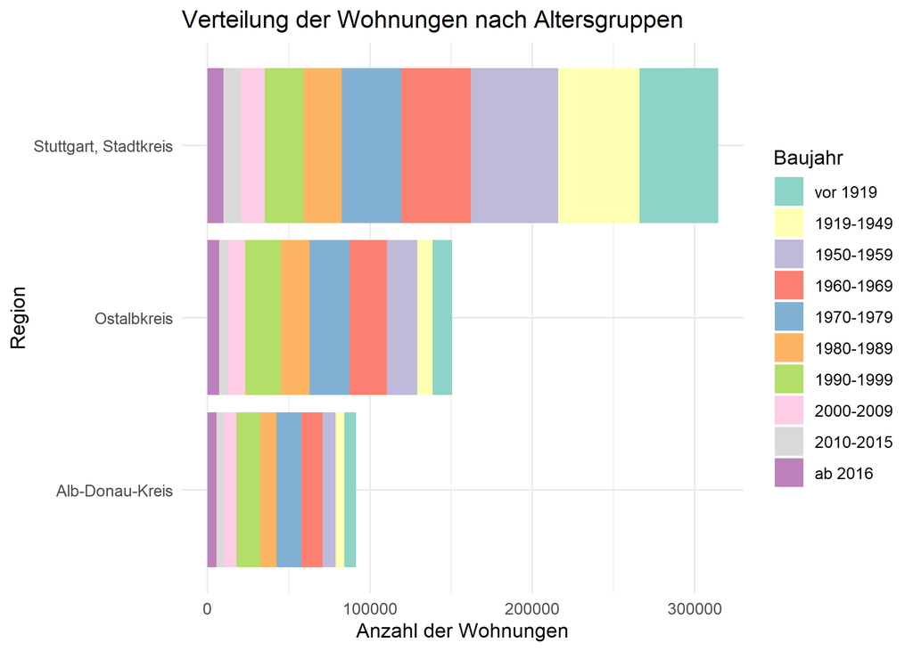

Beschreiben: Die Überschrift der Grafik lautet “Verteilung der Wohnungen nach Altersgruppen” und die y-Achse ist nach den Regionen/ Stadtkreisen “Stuttgart, Stadtkreis”, “Ostalbkreis” und “ALb-Donau-Kreis” eingeteilt. Auf der x-Achse wird die Anzahl der Wohnungen dargestellt. Dadurch kann man die Anzahl der Wohnungen in jeder dieser Regionen ablesen. Diese Anzahl wird dann noch farblich unterteilt in 10 verschiedene Gruppen. Von “vor 1919” bis “ab 2016”. Diese Gruppen sind mit der 3. Farbpalette des Befehls “scale_fill_brewer” gut sichtbar getrennt. Dabei ist die Legende mit der Farbzuteilung am rechten Rand angeordnet, um die Grafik übersichtlich zu machen.

Wenn man nun auf die einzelnen Regionen schaut, dann fällt auf, dass Stuttgart deutlich mehr Wohnungen insgesamt besitzt, aber auch überdurchschnittlich viele Altbauten. Zu sehen ist, dass, grob gesagt, je weiter weg das Jahrzehnt von heute entfernt ist, desto mehr Wohnungen wurden dort gebaut. Somit ist über die Jahrzehnte eine deutlicher Abwärtstrend beim Wohnungsbau zu erkennen.

Das sieht im Ostalbkreis und im Alb-Donau-Kreis anders aus. Bei beiden wird über die Jahrzehnte ungefähr gleich viel gebaut. Allerdings mit der Ausnahme, dass die Jahrzehnte, in denen sie eher in der Mitte liegen, einen deutlich höheren Anstieg der Wohnungen bewirkt haben.

Interpretation: Dass Stuttgart sehr viele Altbauwohnungen hat, könnte daran liegen, dass Stuttgart eine sehr große, dicht bebaute Stadt ist, bei der viel Verkehr herrscht und generell sehr wenig Platz zur Verfügung steht. Das macht es einerseits schwierig, überhaupt noch Baugrundstücke an begehrten Standorten zu finden und das macht das Bauen auch sehr teuer. Zudem ist es auch nicht einfach, alte Gebäude abzureißen, weil alles so dicht bebaut ist.

Auf dem Land hingegen besteht sehr viel Platz und es gibt genügend Baugrundstücke. Durch eine geringere Nachfrage fürs Bauen sind auch die Preise geringer. Das begünstigt Neubauten. Außerdem haben ländliche Regionen eher ein stetiges Bevölkerungswachstum im Gegensatz zu Großstädten. Denn wie man auch in der Grafik sieht, wurden innerhalb von 4 Jahrzehnten über die Hälfte aller bestehenden Wohnungen gebaut. Das spricht für einen sehr starken Bevölkerungsanstieg.

Um dem entgegenzuwirken, dass immer weniger Wohnraum geschaffen wird, können leerstehende Bürogebäude zu Wohnungen umgebaut werden. Zudem konnte die Politik durch Subventionen mehr Anreize für Investitionen schaffen. Ebenso könnte ein umfangreicher Ausbau des öffentlichen Verkehrsnetzes dafür sorgen, dass auch etwas entferntere Stadtteile für Investoren attraktiver werden. Somit hat die Politik viele verschiedene Möglichkeiten, um das Problem in den Griff zu bekommen.

In einem weiteren Schritt sollen Sie nun die Mietpreise und deren Verteilung analysieren. Hierbei sollen Sie neben der Leerstands- und Eigentümerquote auch auf die Verteilung der Wohnungen nach deren Wohnfläche achten und diese untersuchen.

17 (a). Erstellen Sie zuerst eine Tabelle, die die durchschnittlichen Mietpreise mit der Leerstands- und Eigentümerquote darstellt. Was fällt ihnen dabei besonders auf? Beschreiben und interpretieren Sie ihre Tabelle.

17 (b). Erstellen Sie eine weitere Grafik, die die Verteilung der Wohnungen nach den einzelnen Wohnungsgrößen(<40m² bis >=200m²) abbildet. Stellen Sie darüber hinaus den durchschnittlichen Mietpreis je Landkreis in einer weiteren Grafik dar. Beschreiben und interpretieren Sie ihre Grafiken. Gehen Sie insbesondere auf die Frage ein, ob es Sinn macht sich vor allem den Ostalbkreis oder Alb-Donau-Kreis als ein Ganzes anzusehen und inwieweit überhaupt ein Vergleich zwischen Stadt und ländlicher Region möglich ist.

*Hinweis:* Hier sollen Sie erneut auf dieselben Städte und Landkreise aus Aufgabe 16 eingehen!

```
## # A tibble: 3 × 4
##   Landkreis               LEQ   ETQ Durchschnitts_Miete
##   <chr>                 <dbl> <dbl>               <dbl>
## 1 Alb-Donau-Kreis        5.34  71.4                712.
## 2 Ostalbkreis            5.09  70.6                648.
## 3 Stuttgart, Stadtkreis  3.46  31.2                721.
```

Beschreiben: In der Tabelle wird zu den drei Landkreisen “Alb-Donau-Kreis”, “OStalbkreis” und “Stuttgart, Stadtkreis” die Leerstandsquote mit LEQ, Eigentümerquote mit ETQ und durchschnittlichen Mietpreise mit Durchsnitts_Miete dargestellt.

Interpretation + detaillierte Beschreibung: Bei der Leerstandsquote ist auffällig, dass Stuttgart im Vergleich zu den anderen beiden eine sehr niedrige Leerstandsquote mit 3.46 hat. Das ist allerdings mit der hohen Nachfrage nach Wohnraum in Stuttgart zu erklären. Die anderen beiden Landkreise haben eine sehr ähnliche Leerstandsquote mit 5.33 und 5.09 , was nicht sehr überraschend ist, da es sich dabei um einen relativ normalen Wert handelt. Das liegt daran, dass es sich um ländliche Standorte handelt, wo der Wohnraum nicht so knapp ist wie in Großstädten wie Stuttgart.

Auch bei der Eigentümerquote sind sich die Landkreise “Alb-Donau-Kreis” mit 71.44 und 70.6 sehr ähnlich. Auch das ist nicht überraschend, da in ländlichen Regionen viele Personen die Wohnungen besitzen eher Privatpersonen sind, die ihre Immobilie selber nutzen. Das sieht in Großstädten anders aus, wie man an den Zahlen von Stuttgart sehen kann. Dort ist die Eigentümerquote nur bei 31.15 Prozent. Das ist damit zu erklären, dass die Wohnungen dort eher Immobilieninvestoren gehören, die Geld mit der Vermietung von Wohnungen machen. Dieser drastische Unterschied in den beiden Konzepten, mit der Immobilie umzugehen, liegt daran, dass Wohnraum in Großstädten sehr gefragt ist, was die Situation in Großstädten für Investoren sehr attraktiv macht. Denn in der Großstadt haben sie ein deutlich geringeres Risiko, dass sie ihre Immobilie nicht vermietet bekommen. Zudem sind die Preise, die für die gleiche Wohnung verlangt werden , in der Stadt viel größer.

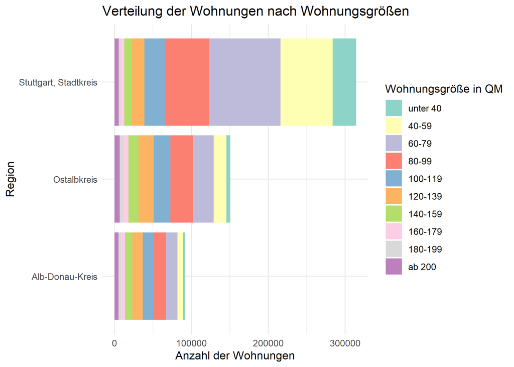

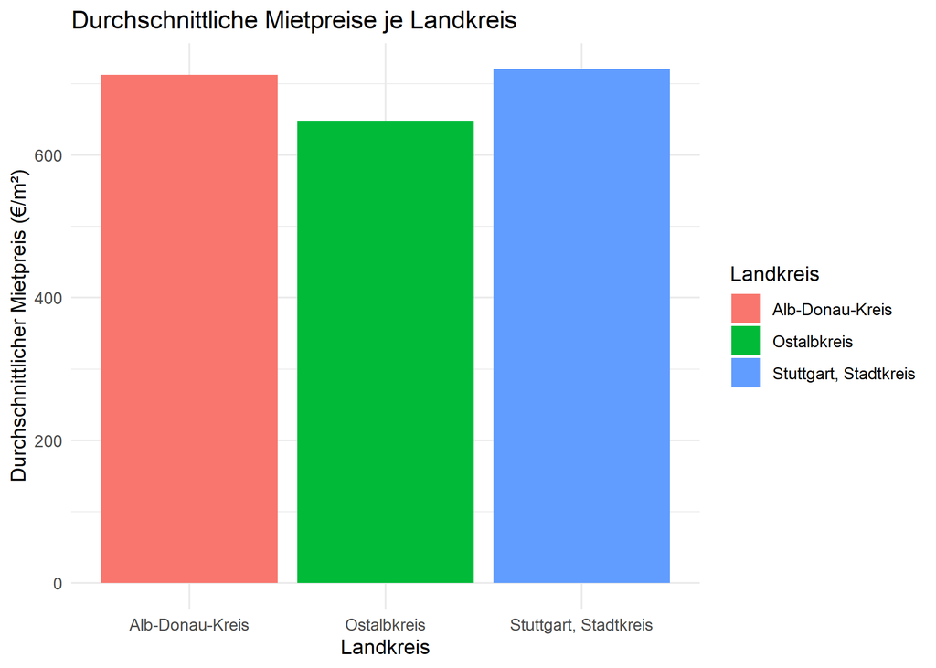

Beschreibung Grafik 1: Auf der y-Achse sind die Landkreise “Stuttgart, Stadtkreis”, “Ostalbkreis” und “Alb-Donau-Kreis” zu sehen. Auf der x-Achse wird die Anzahl der Wohnungen dargestellt und bei der Grafik handelt es sich um ein ” stacked Balkendiagramm”. Die Anzahl der Wohnungen wurde nach der Wohnungsgröße eingefärbt, wobei die Wohnungsgröße immer in 20 Quadratmeter Schritten abläuft. So ist die kleinste Wohnung kleiner als 40 Quadratmeter und die größte ab 200 Quadratmeter. Die Überschrift der Grafik lautet ” Verteilung der Wohnungen nach Wohnungsgröße”.

Es ist deutlich zu erkennen, dass in allen drei Landkreisen mittelkleine und mittelgroße wohnungen von 40 bis 99 Quadratmeter am häufigsten vorkommen. Zudem ändert sich die Anzahl an großen Wohnungen nicht, obwohl Stuttgart doppelt so viele Wohnungen insgesamt hat. Somit haben alle drei Landkreise ungefähr gleich viele sehr große Wohnungen zwischen 140 und 200 Quadratmetern. Außerdem gibt es bei den ländlichen Landkreisen deutlich weniger sehr kleine Wohnungen.

Beschreibung Grafik 2: Die Überschrift der Grafik lautet “Durchschnittliche Mietpreise je Landkreis”. Auf der x-Achse sind die drei Landkreise “Stuttgart, Stadtkreis”, “Alb-Donau-Kreis” und “Ostalbkreis” dargestellt und auf der y-Achse die durchschnittlichen Mietpreise in Euro pro Quadratmeter. Auf der rechten Seite der Grafik befindet sich die Legende, wo den Landkreisen jeweils eine Farbe zugeordnet wird. Der Ostalbkreis ist grün eingefärbt und hat die geringste durchschnittliche Miete und Stuttgart ist blau eingefärbt und hat die höchste durchschnittliche Miete.

Interpretation: Den Ostalbkreis oder Alb-Donau-Kreis als ein ganzes zu betrachten ist wenig sinnvoll, da sie eine sehr große fläche abdecken ,welche zwar zum großteil aus kleinen Dörfern besteht, aber der Alb-Donau-Kreis hat zum Beispiel ein Industriegebiet in Erbach, was wiederum für Arbeitsplätze sorgt, was in der Region die Mieten erhöht. So wird durch ein kleines Gebiet der Durchschnitt sehr verzerrt, obwohl der Rest nur kleine Dörfer sind. Somit ist es schwer den Alb-Donau-Kreis mit dem Ostalbkreis zu vergleichen und diese Regionen überhaupt als Ganzes zu sehen. Gerade in Bezug auf eine solche Datenauswertung.

Der Vergleich zwischen Stadt und ländlichen Regionen ist auch schwer, da in einer Stadt viel auf einen geringen Raum komprimiert ist, wohingegen auf dem Land alles etwas weiter auseinander liegt. Dadurch gibt es auf dem Land üblicherweise viel größere Wohnungen und in der Stadt eher kleine. Zudem gibt es so viele Einflüsse wie Öffentlicher Nahverkehr oder mögliche Arbeitgeber, die in der Nähe angesiedelt sind, die einen puren Vergleich von Durchschnittswerten deutlich weniger aussagekräftig machen. Ganz davon abgesehen, dass das Stadtleben und das Landleben von Grund auf unterschiedliche Werte vertreten. Wenn man an Stadtleben denkt man an viele Personen auf engem Raum. Nachbarn, die sich kaum kennen. Supermärkte, die zwei Minuten entfernt sind und von denen es in der Nähe 10 verschiedene gibt. Landleben hat jedoch etwas Familiäres. Jeder kennt jeden. Es gibt meist den einen Bäcker und den einen lokalen Metzger, zu dem jeder hingeht. Jedes Haus hat einen Garten und man muss nur fünf Minuten zum nächsten Wald laufen.

Das sind ganz unterschiedliche Lebensweisen, die durch die Regionen verkörpert werden, was einen aussagekräftigen Vergleich sehr schwer macht.

# Zusatzfrage (optional)

Diese Frage ist von der Bearbeitung her etwas schwieriger. Bevor Sie sich an diese Aufgabe machen, sollten Sie sicherstellen, dass Sie alle vorherigen Fragen ausführlich beantwortet haben. Eine korrekte Beantwortung dieser Frage gibt einen Punktebonus von 3 Punkten (das Projekt umfasst insgesamt 30 Punkte, inkl. Screencast).

Nachdem Sie sich in den bisherigen Aufgaben ausführlich mit den allgemeinen Einflussfaktoren auf die Mietpreise befasst haben, rückt nun ein spezifischer Aspekt in den Fokus: die Rolle der Heizungen. Insbesondere werden Sie untersuchen, wie unterschiedliche Heizungsarten und -systeme die Mietpreise beeinflussen können. Diese Betrachtung ermöglicht es ihnen, die bisherigen Analysen zu verfeinern und den Zusammenhang zwischen energetischen Standards und der Entwicklung von Mietkosten genauer zu erfassen. Aufgabe 18 führt Sie somit zu einem weiteren zentralen Detail der Mietpreisentwicklung, das insbesondere vor dem Hintergrund steigender Energiepreise und der Relevanz nachhaltiger Wohnformen an Bedeutung gewinnt.

18. Lesen Sie den Datensatz `Heiztypen_Zensus.csv` ein und speichern diesen als `heiztypen` ab. Neben den Ihnen bekannten Variablen, finden Sie dort 6 weitere Variablen, die Auskunft über die Heizarten der jeweiligen Wohnung geben. Diese werden wie folgt beschrieben:
- HEIZTYP__1: Gebäude mit Heizungsart Fernheizung (Fernwärme) (Anzahl)
- HEIZTYP__2: Gebäude mit Heizungsart Etagenheizung (Anzahl)
- HEIZTYP__3: Gebäude mit Heizungsart Blockheizung (Anzahl)
- HEIZTYP__4: Gebäude mit Heizungsart Zentralheizung (Anzahl)
- HEIZTYP__5: Gebäude mit Heizungsart Einzel- oder Mehrraumöfen (auch Nachtspeicherheizung) (Anzahl)
- HEIZTYP__6: Gebäude mit Heizungsart Keine Heizung im Gebäude oder in den Wohnungen (Anzahl)

Erstellen Sie eine neue Spalte `heiztypen_gesamt`, welche die Summe über alle Heiztypen hinweg bildet. Bestimmen Sie weiterhin den Anteil der jeweiligen Heiztypen je Gemeinde (als Anteil aller Heizarten). Nun sollen Sie eine oder mehrere passende Grafik(en) erzeugen, die je nach durchschnittlicher Größe der Wohnungen die Anteile der verschiedenen Heizungsarten abbilden. Erstellen Sie weiterhin eine oder mehrere passende Grafik(en) die den Zusammenhang zwischen den Heizungsarten und den durschnittlichen Mietpreisen darstellt. Wiederum soll der Anteil der verschiedenen Heizungsarten abhängig der Mietpreise abgebildet werden.

Beschreiben und interpretieren Sie ihre Schaubilder und gehen Sie insbesondere auf folgende Frage ein:

- Gibt es einen Zusammenhang zwischen der Heizungsart und der Größe der Wohnungen?
- Gibt es einen Zusammenhang zwischen der Heizungsart und den Mietpreisen?
- Was könnten Gründe sein, warum in bestimmten Wohnungsgrößen eher bestimmte Heizungstypen eingebaut werden und andere nicht?
- Warum könnte es sein, dass bei manchen Heizungsarten die Mietpreise höher sind als bei anderen?
- Was könnte die Bundesregierung machen, um trotz neuer und moderner Heizungssysteme die Mietpreise nach oben hin zu beschränken?

*Hinweis 1:* Überlegen Sie sich, ob es ihrer Ansicht nach Sinn macht, die jeweiligen Wohnungsgrößen und durchschnittlichen Mietpreise in Segmente zu unterteilen.

*Hinweis 2:* Eine Möglichkeit die Beziehung zwischen Heizungsarten und Wohnungsgrößen bzw. Heizungsarten und Mietpreisen zu visualisieren wäre beispielsweise ein “stacked” oder “grouped” Balkendiagramm. Überlegen Sie sich, warum diese Form der Darstellung besonders gut geeignet wäre.

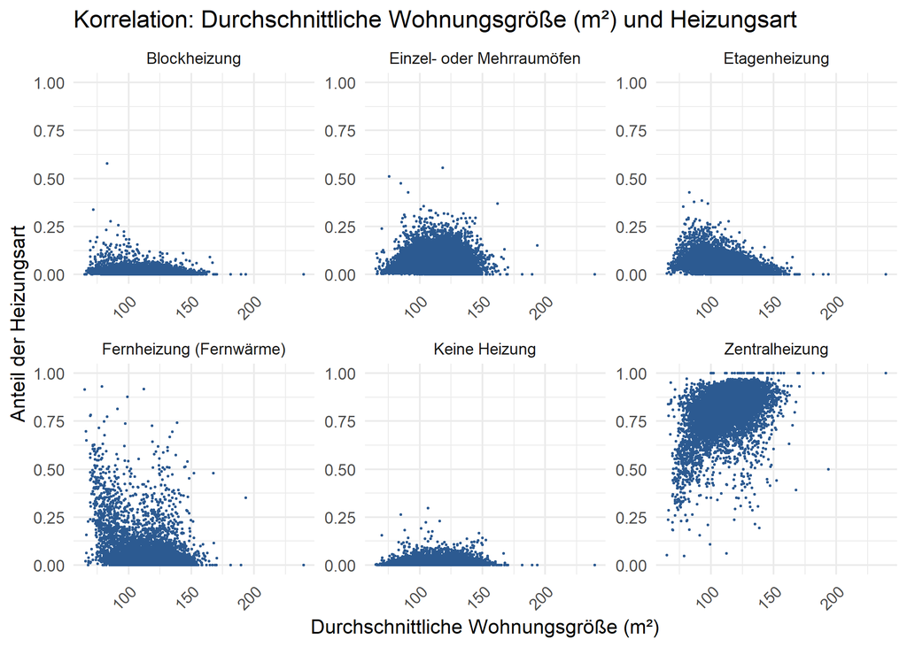

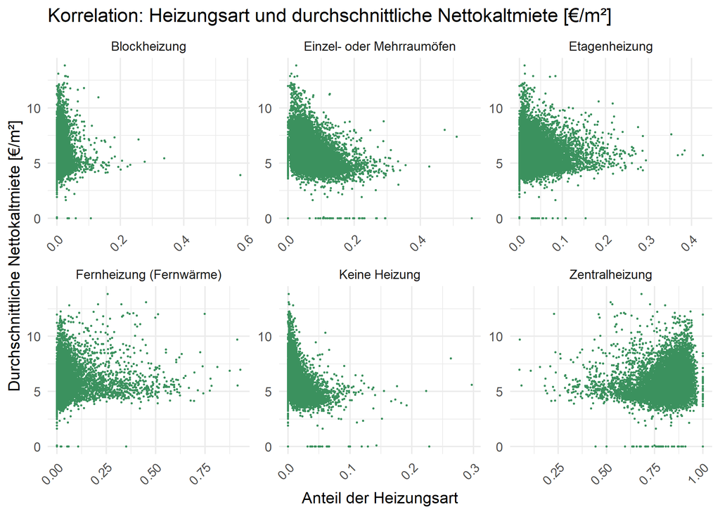

Der häufigere Einsatz bestimmter Heizungen in spezifischen Wohnungsgrößen könnte mit Effizienzüberlegungen zusammenhängen: Zentralheizungen eignen sich aufgrund ihrer Skalierbarkeit besser für größere Gebäude, während Einzelöfen für kleinere Einheiten kostengünstiger zu installieren sind. Zudem wird Fernwärme durch die höhere Wirtschaftlichkeit - die sich aus einer höheren Nachfrage und weniger Energieverlust durch geringere Strecken ergibt - zumeist in urbanen Gebieten eingesetzt, wo die durchschnittliche Wohnfläche oft niedriger ist als in ländlicheren Gebieten.

Um steigende Mietpreise trotz moderner Heizungssysteme zu begrenzen, könnte die Bundesregierung Maßnahmen wie Mietpreisdeckel, steuerliche Anreize für Vermieter oder Subventionen für den Einbau effizienter und klimafreundlicher Heizungen ergreifen. Gleichzeitig könnte die Förderung von Fernwärmenetzen oder standardisierte Kostenkontrollen für Heizsysteme helfen, soziale Ungleichheiten zu minimieren.

Wie Sie in der Aufgabe 15 gesehen haben, haben Ulm und Stuttgart, sowie Dresden und Chemnitz ähnliche Verhältnisse bezüglich der Verteilung der Mietkosten über die Stadt hinweg. Aufgrund dessen beschränken Sie sich bei dieser Aufgabe auf die Städte Stuttgart und Dresden. Hier sollen Sie sich die einzelnen Heizungsarten über die Stadtteile hinweg anschauen, wie sich diese verteilen und ob hier Ähnlichkeiten zur Mietpreissstrukur vorliegt. Weiterhin sind vor allem die Heizungsarten Fernwärme, Zentralheizung und Etagenheizung in viele deutschen Wohnungen größtenteils verbaut, weshalb Sie gerade deswegen diese drei Heiztypen genauer beleuchten und untersuchen sollen.

19. Deshalb sollten Sie sich in einem ersten Schritt [diese Geogitter-Daten für die verschiedenen Heinzungsarten vom statistischen Bundesamt herunterladen](https://www.zensus2022.de/static/Zensus_Veroeffentlichung/Zensus2022_Heizungsart.zip). Speichern Sie die zip-Datei im Ordner `Daten` ab. Nutzen Sie erneut den Datensatz shape_file aus der Aufgabe 4 und joinen Sie die Informationen zu den Heizungsarten über die Variablen `x_mp_1km` und `y_mp_1km`.

In ihrem Datensatz können Sie sehen, dass es Einträge mit “-” gibt. Diese sollen sie für alle Heizungstypen durch 0 ersetzen. Achten Sie auch darauf, dass über alle Heizungstypen hinweg die Werte als numeric vorliegen.

Erstellen Sie nun für die Heizungsarten “Fernheizung”, “Etagenheizung” und “Zentralheizung” eine neue Spalte mit dem Anteil des jeweiligen Heizungstyps an allen Heizungen (`Insgesamt_Heizungsart`) je Gemeinde. Schließlich sollen Sie nun für die drei genannten Heizungsarten eine Karte erzeugen, welche den Anteil je Gitterebene im Stadtbezirk darstellt.

Beschreiben und interpretieren Sie ihre Grafiken. Berücksichtigen Sie dabei insbesondere folgende Fragen:

- Wo liegen Besonderheiten oder Muster in beiden Städten?
- Gibt es in Stuttgart und Dresden Stadtteile, bei denen bestimmte Heizungstypen in Einklang mit den Mietpreisen stehen, genauer gesagt, welche Heizungsarten korrelieren mit höheren oder niedrigeren Mietpreisen? Vergleichen Sie dazu die Ergebnisse aus Aufgabe 15.
- Was könnten Gründe sein, dass in bestimmten Stadtteilen vorwiegend eine bestimmte Form der Heizung eingebaut ist?
- Gibt es Unterschiede zwischen Ost- und Westdeutschland?
- Haben die Städte Stuttgart oder Dresden in den letzen Jahren Modernisierungen angestoßen oder Neuerungen umgesetzt und finanziell unterstützt, sodass es dort zu größeren Anpassungen bei der Heizungstechnik kam?

*Hinweis 1:* Sie sollen insgesamt für jede Stadt (Stuttgart und Dresden) drei verschiedene Karten erzeugen.

*Hinweis 2:* Achten Sie auf eine sinnvolle Einteilung und Darstellung in den Karten. Nutzen Sie die Karten aus vorherigen Aufgaben als Hilfestellung.

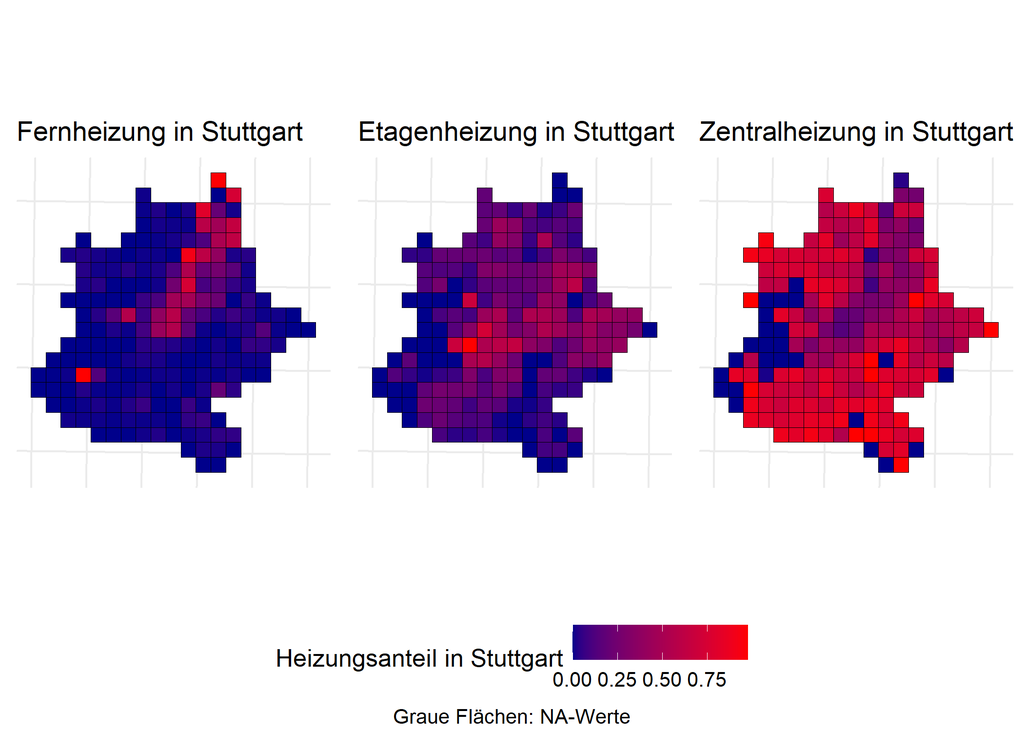

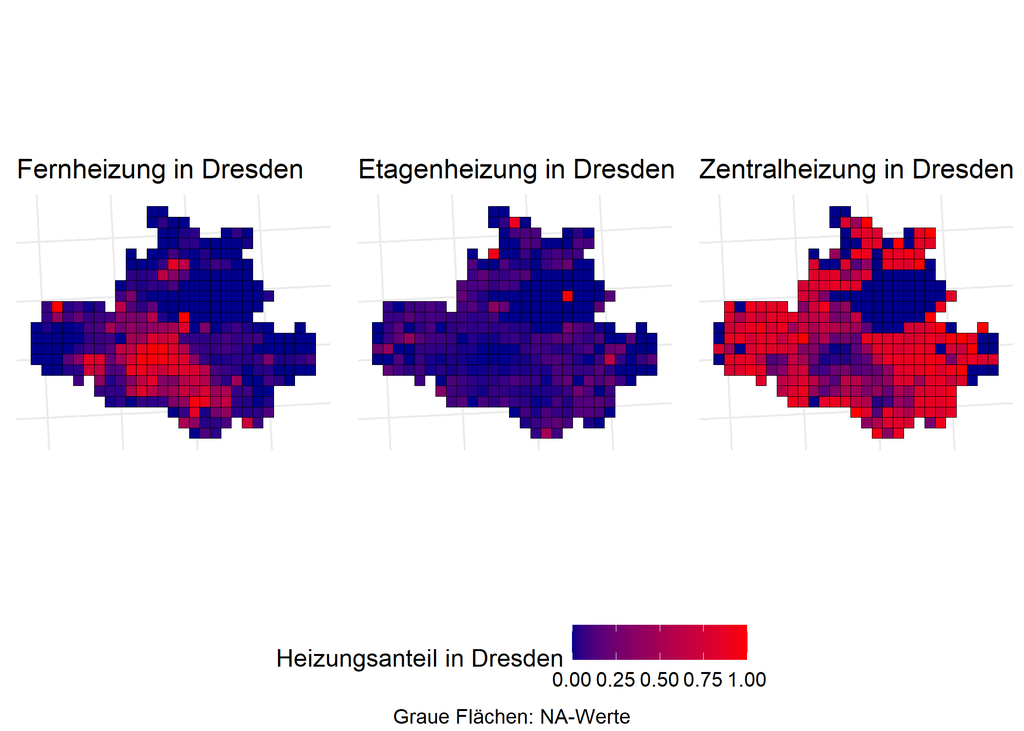

Beschreibung: Zu sehen sind zwei Grafiken, die die Heizungsarten in Stuttgart und Dresden darstellen. Auf jeder dieser Übersichtsgraphiken sind drei separate Diagramme zu erkennen, in denen der Anteil an Fernheizungen, Etagenheizungen und Zentralheizungen visualisiert wird. Die Werte sind mit einem Farbverlauf von dunkelblau (für niedrige Werte) bis rot (für hohe Werte) eingefärbt, entsprechend der Farblegende am unteren Rand der Grafiken.

Weiterhin lässt sich beobachten, dass Dresden kaum Etagenheizungen aufweist, oder diese sehr verstreut in Wohngebieten zu finden sind, während Stuttgart klar sichtbare Bereiche mit Fernheizungen hat, insbesondere in der Stadtmitte, aber auch im Osten der Stadt. Dieses Phänomen könnte auch auf den Unterschied zwischen Ost- und Westdeutschland hindeuten, wo die Verteilung der Heizungsarten markante Unterschiede zeigt. Was die Verbreitung der Heizungsarten angeht, gibt es plausible Erklärungen: Dresden, als Teil der ehemaligen DDR, weist viele Fernheizungen auf. Diese stammen aus der Zeit der zentral geplanten Infrastruktur der DDR, in der große Wohnblocks bevorzugt zentrale Heizungsquellen nutzten. Zentralheizungen wurden historisch oft, insbesondere in Mehrfamilienhäusern, verbaut und sind daher europaweit, auch in Stuttgart, heute noch weit verbreitet. Etagenheizungen erscheinen in Stuttgart häufiger, was damit in Verbindung gebracht werden könnte, dass sie sich besonders in kleineren und älteren Wohnungen, wie in Stadtteilen wie Heslach oder Degerloch, die es in Stuttgart zahlreich gibt, befinden. Zudem waren sie in Westdeutschland verbreiteter als in Ostdeutschland.

Abschließend betrachten wir, ob in den letzten Jahren in diesen Städten bestimmte Modernisierungs-Initiativen oder Unterstützungen für Neuerungen unternommen wurden, die zu wesentlichen Anpassungen der Heizungstechnik führten. Beide Städte engagieren sich stark im Ausbau der Fernwärmeversorgung. Das erklärt, warum in Stuttgart ebenfalls Fernheizungen vorzufinden sind, obwohl sie bei weitem nicht so oft wie in Dresden vorkommen. Dresden hatte auf Grundlage von Förderprogrammen, wie dem “Dresdner Klimaschutzkonzept”, den Vorteil bestehender ausgedehnter Fernwärmenetze, die eher modernisiert und erweitert als neu eingerichtet werden mussten – ein Vorteil, den Stuttgart nicht hatte. In Stuttgart hingegen wurden zum Beispiel im Rahmen des “Stuttgarter Energieprogramms” gezielt Förderungen für die Installation von Fernwärmeanschlüssen bereitgestellt, wobei besonders Neubauten gefördert wurden, um die Verbreitung zu erhöhen. Zusammenfassend lässt sich feststellen, dass sich der Ausbau und die Modernisierung der Heizungstechnik in beiden Städten stark auf die Förderung der Fernwärme konzentriert hat. Ziel ist es dabei, Heizungsarten zu modernisieren, um sie umweltfreundlicher zu gestalten und CO2-Emissionen zu reduzieren.

Abschließend sollen Sie die Zusatzaufgabe noch einmal rekapitulieren und einige Fragen dazu beantworten.

20. Sie sollen sich noch einmal bewusst werden, was Sie in den vorherigen Aufgaben analysiert haben und in welcher Form ihre Ergebnisse anwendbar und verallgemeinbar sind. Beantworten Sie dazu Frage 1 und 2.

Frage 1: Betrachten Sie hierzu noch einmal exemplarisch die Städte Stuttgart und Dresden.

- Sind die Zusammenhänge zwischen Mietpreisen in den Städten und sozioökonomischer Faktoren vor allem auf Unterschiede zwischen den Städten oder auf Unterschiede innerhalb der Stadt zurückzuführen. Bei welchen Faktoren ist dies der Fall, wo nicht?
- Wie kann der Staat im Hinblick auf die unterschiedlichen Heizungsarten in den Städten eingreifen, um Wohnraum preiswerter zu gestalten?

Frage 2: Schauen Sie sich noch einmal die Verteilung der Heizungsarten (Fern-, Etagen- und Zentralheizungen) für Stuttgart und Dresden in Aufgabe 19 an. Betrachten Sie im Vergleich dazu ihre Grafik aus Aufgabe 8, sowie ihre Tabelle in Aufgabe 13?

- Was fällt Ihnen hier auf?
- Gibt es bestimmte Heizungstypen, die nur in alten oder neuen Wohnungen vorkommen?
- Welche Schlüsse würden Sie ziehen, die mit Handlungen der Politik einhergehen?

[output not shown]